# Enunciado

Trabajamos como científicos de datos para una empresa de retail que, debido al cambio en los hábitos de consumo de los clientes, está potenciando ampliamente el servicio de venta online. La empresa quiere realizar un modelo de aprendizaje automático para clasificar a los clientes en función de la probabilidad de generar ingresos al comprar en la web. El objetivo es realizar una serie de acciones específicas para los clientes que es más probable que hagan compras en la web.

Para ello, la empresa ha ido recopilando datos con su herramienta de Google Analytics. Cuenta con datos de sesiones, cada una de ellas de un cliente distinto en un periodo de un año.

#### Se pide

Tareas que nos pide la empresa:

- 1. Realización de un análisis de las variables del dataset de Google Analytics como pueden ser histogramas, boxplots, etc. Cualquier otro análisis es bienvenido, siempre explicándolo y con un sentido de negocio.
- 1. Tratamiento de los valores faltantes, outliers, etc., en caso de que los hubiese. Si hay valores con missings, habrá que eliminarlos con el método de Pandas llamado Dropna().a.
- 1. Tratamiento de categóricas, pasándolas a numéricas por medio de dummies, mapeándolas o utilizando un label encoder. Hay que justificar las operaciones que se realizan.
- 1. Si existe alguna variable que se necesite borrar, habrá que borrarla y justificarlo.
- 1. Estandariza los datos.
- 1. Dividir los datos en train y en test. Con los datos de train se pretende ajustar modelos con CrossValidation y GridSearch.
- 1. Utilizar un modelo lineal. Entre los modelos lineales están las regresiones logísticas, las regresiones lineales, etc.
- 1. Utilizar un modelo de redes neuronales.
- 1. Utilizar cualquier otro modelo de clasificación.
- 1. Optimizar algún parámetro de cada modelo utilizando CrossValidation y GridSearch, o de la forma que se estime oportuna, siempre justificándolo.
- 1. Elegir el mejor modelo de los tres según la métrica ROC en CrossValidation. Predecir Test y obtener una métrica estimada.
- 1. Umbralizar las probabilidades utilizando el umbral que maximice el área bajo la curva ROC.
- 1. El entregable final será un Jupyter Notebook en el que se realicen todos los análisis y los modelos.

#### NOTAS:

Lo que se pide es un modelo end-to-end como los vistos en prácticas en el módulo. En este caso, hay que aplicar tres modelos y escoger el mejor, pero la parte previa es común a los tres.

Se tendrán en cuenta la estructura del código, las interpretaciones y las justificaciones.

El esquema que se pone en las tareas es un esquema general. Si se necesita hacer alguna tarea, se puede llevar a cabo. También es posible aplicar cualquier otro algoritmo visto en el módulo, siempre justificando y haciendo las cosas con un sentido.

#### Información de los datos:

El conjunto de datos consta de diez atributos numéricos y ocho categóricos.

- El atributo *revenue* puede ser usado como la etiqueta de la clase.
- *Administrative*, *administrative duration*, *informational*, *informational duration*, *product related* y *product related duration* representan el número de diferentes tipos de páginas visitadas por el visitante en esa sesión y el tiempo total dedicado a cada una de estas categorías de páginas. Los valores de estas características se derivan de la información del URL de las páginas visitadas por el usuario y se actualizan en tiempo real cuando el usuario realiza una acción, por ejemplo, pasar de una página a otra.
- Las características *bounce rate*, *exit rate* y *page value* representan las métricas medidas por Google Analytics para cada página del sitio de comercio electrónico. El valor de la característica *bounce rate* de una página web se refiere al porcentaje de visitantes que entran en el sitio desde esa página y luego salen (rebote) sin activar ninguna otra solicitud al servidor de análisis durante esa sesión. El valor de la característica *exit rate* para una página web específica se calcula como para todas las visitas a la página, el porcentaje que fueron las últimas en la sesión. La función *Page Value* representa el valor medio de una página web que un usuario ha visitado antes de completar una transacción de comercio electrónico.
- La característica de *special day* indica la cercanía de la hora de visita del sitio a un día especial específico (por ejemplo, el Día de la Madre, San Valentín) en el que es más probable que las sesiones finalicen con una transacción. El valor de este atributo se determina teniendo en cuenta la dinámica del comercio electrónico, como la duración entre la fecha del pedido y la fecha de entrega. Por ejemplo, para San Valentín, este valor toma un valor distinto de 0 entre el 2 y el 12 de febrero, 0 antes y después de esta fecha a menos que esté cerca de otro día especial, y su valor máximo de 1 el 8 de febrero.
- El conjunto de datos también incluye el sistema operativo, el navegador, la región, el tipo de tráfico, el tipo de visitante como visitante que regresa o como nuevo visitante, un valor booleano que indica si la fecha de la visita es de fin de semana, y el mes del año.
- Los datos se han obtenido de la siguiente web, aunque se pueden descargar de la plataforma de IMF Business School: https://archive.ics.uci.edu/ml/datasets/Online+Shoppers+Purchasing+Intention+Dataset

```python
# Librerías
import pandas as pd
import numpy as np
import warnings
from sklearn.preprocessing import OneHotEncoder, StandardScaler
import statsmodels.api as sm
from sklearn.decomposition import PCA
from sklearn.neighbors import LocalOutlierFactor
from sklearn.model_selection import GridSearchCV, train_test_split, cross_val_score
from sklearn.linear_model import LogisticRegression
from sklearn.metrics import f1_score, precision_score, recall_score, roc_auc_score, roc_curve, r2_score, auc
from sklearn.ensemble import RandomForestClassifier
from tensorflow.keras.models import Sequential
from tensorflow.keras.layers import Dense
from tensorflow.keras.callbacks import EarlyStopping
import seaborn as sns
import matplotlib.pyplot as plt
import matplotlib.patches as mpatches
import matplotlib.axes as axes
%matplotlib inline
warnings.filterwarnings('ignore')
```

```python
# Funciones
# Comprobar integridad de las variables categóricas
def comprobar_categorias(_categories):
    for categ in _categories:
        print(f"{categ}: {df[categ].cat.categories}")


# Eliminar errores de variables (Sólo válido para eliminar errores con valor -1 en variables de tiempo)
def drop_errors(_categories):
    for categ in _categories:
        df.drop(df[df[categ] == -1].index, axis=0, inplace=True)


# Dibujar histogramas de una lista de variables haciendo facetting por Revenue
def histograma_facetting_revenue(_variable):
    fig, axes = plt.subplots(nrows=1, ncols=len(_variable), figsize=(15, 5))
    axes = axes.flatten()

    for i, var in enumerate(_variable):
        sns.histplot(data=df, x=var, hue='Revenue', multiple='stack', ax=axes[i], palette={True: 'green', False: 'red'})
        axes[i].set_title(f'Histograma de {var}')
        axes[i].set_xlabel(var)
        axes[i].set_ylabel('Frecuencia')

    plt.tight_layout()
    plt.show()


# Dibujar histogramas de SpecialDay haciendo facetting por Revenue
def histograma_specialday_revenue(_revenue_true, _revenue_false):
    plt.hist([_revenue_true, _revenue_false], bins=5, color=['green', 'red'],
            label=['Revenue True', 'Revenue False'], edgecolor='black', stacked=True)
    plt.xlabel('Cercanía a día especial')
    plt.ylabel('Frecuencia')
    plt.title('Frecuencias de interacción por cercanía a día especial')

    plt.tight_layout()
    plt.show()


# Dibujar diagramas circulares
def diagrama_circular_frecuencias(_variable):
    fig, axs = plt.subplots(1, len(_variable), figsize=(18, 6))

    for i, var in enumerate(_variable):
        counts = df[var].value_counts()
        axs[i].pie(counts, labels=counts.index, autopct='%1.1f%%', shadow=False, startangle=90)
        axs[i].axis('equal')
        axs[i].set_title(var)

    plt.tight_layout()
    plt.show()


# Dibujar diagramas de barras haciendo facetting por Revenue
def barras_facetting_revenue(_variable):
    if(len(_variable)>1):
        fig, axes = plt.subplots(nrows=1, ncols=len(_variable), figsize=(15, 5))
        axes = axes.flatten()

        for i, var in enumerate(_variable):
            sns.countplot(data=df, x=var, hue='Revenue', ax=axes[i], palette={True: 'green', False: 'red'})
            axes[i].set_title(f'Distribución de {var}')
            axes[i].set_xlabel(var)
            axes[i].set_ylabel('Frecuencia')
    else:
        plt.figure(figsize=(8, 4))
        sns.countplot(data=df, x=_variable[0], hue='Revenue', palette={True: 'green', False: 'red'})
        plt.title(f'Distribución de {_variable[0]}')
        plt.xlabel(_variable[0])
        plt.ylabel('Frecuencia')

    plt.tight_layout()
    plt.show()


# Para estandarizar el dataset original con el que se entrena y valida el modelo y posteriores datasets
def standard_dataset(_x):
    scaler = StandardScaler()

    for var in _x.columns:
        _x[var] = scaler.fit_transform(_x[[var]])

    return _x


# Para obtener las métricas comparando los valores de test con los valores de las predicciones
def get_metrics(_y_test, _y_test_pred, _y_test_prob):
    auc = round(roc_auc_score(_y_test, _y_test_prob),2)
    precission = round(precision_score(_y_test, _y_test_pred),2)
    recall = round(recall_score(_y_test, _y_test_pred),2)
    f1score = round(f1_score(_y_test, _y_test_pred),2)
    print(f"- Precission: {precission}\n- Recall: {recall}\n- F-score: {f1score}\n- AUC: {auc}")

    return [precission, recall, f1score, auc]
```

```python
# Carga de los datos
df = pd.read_csv(r"archivos/online_shoppers_intention.csv")
df
```

|  | Administrative | Administrative_Duration | Informational | Informational_Duration | ProductRelated | ProductRelated_Duration | BounceRates | ExitRates | PageValues | SpecialDay | Month | OperatingSystems | Browser | Region | TrafficType | VisitorType | Weekend | Revenue |
| --- | --- | --- | --- | --- | --- | --- | --- | --- | --- | --- | --- | --- | --- | --- | --- | --- | --- | --- |
| 0 | 0.0 | 0.0 | 0.0 | 0.0 | 1.0 | 0.000000 | 0.200000 | 0.200000 | 0.000000 | 0.0 | Feb | 1 | 1 | 1 | 1 | Returning_Visitor | False | False |
| 1 | 0.0 | 0.0 | 0.0 | 0.0 | 2.0 | 64.000000 | 0.000000 | 0.100000 | 0.000000 | 0.0 | Feb | 2 | 2 | 1 | 2 | Returning_Visitor | False | False |
| 2 | 0.0 | -1.0 | 0.0 | -1.0 | 1.0 | -1.000000 | 0.200000 | 0.200000 | 0.000000 | 0.0 | Feb | 4 | 1 | 9 | 3 | Returning_Visitor | False | False |
| 3 | 0.0 | 0.0 | 0.0 | 0.0 | 2.0 | 2.666667 | 0.050000 | 0.140000 | 0.000000 | 0.0 | Feb | 3 | 2 | 2 | 4 | Returning_Visitor | False | False |
| 4 | 0.0 | 0.0 | 0.0 | 0.0 | 10.0 | 627.500000 | 0.020000 | 0.050000 | 0.000000 | 0.0 | Feb | 3 | 3 | 1 | 4 | Returning_Visitor | True | False |
| ... | ... | ... | ... | ... | ... | ... | ... | ... | ... | ... | ... | ... | ... | ... | ... | ... | ... | ... |
| 12325 | 3.0 | 145.0 | 0.0 | 0.0 | 53.0 | 1783.791667 | 0.007143 | 0.029031 | 12.241717 | 0.0 | Dec | 4 | 6 | 1 | 1 | Returning_Visitor | True | False |
| 12326 | 0.0 | 0.0 | 0.0 | 0.0 | 5.0 | 465.750000 | 0.000000 | 0.021333 | 0.000000 | 0.0 | Nov | 3 | 2 | 1 | 8 | Returning_Visitor | True | False |
| 12327 | 0.0 | 0.0 | 0.0 | 0.0 | 6.0 | 184.250000 | 0.083333 | 0.086667 | 0.000000 | 0.0 | Nov | 3 | 2 | 1 | 13 | Returning_Visitor | True | False |
| 12328 | 4.0 | 75.0 | 0.0 | 0.0 | 15.0 | 346.000000 | 0.000000 | 0.021053 | 0.000000 | 0.0 | Nov | 2 | 2 | 3 | 11 | Returning_Visitor | False | False |
| 12329 | 0.0 | 0.0 | 0.0 | 0.0 | 3.0 | 21.250000 | 0.000000 | 0.066667 | 0.000000 | 0.0 | Nov | 3 | 2 | 1 | 2 | New_Visitor | True | False |

12330 rows × 18 columns

```python
# Número de observaciones del dataframe
len(df)
```

```
12330
```

```python
# Columnas
df.columns
```

```
Index(['Administrative', 'Administrative_Duration', 'Informational',
       'Informational_Duration', 'ProductRelated', 'ProductRelated_Duration',
       'BounceRates', 'ExitRates', 'PageValues', 'SpecialDay', 'Month',
       'OperatingSystems', 'Browser', 'Region', 'TrafficType', 'VisitorType',
       'Weekend', 'Revenue'],
      dtype='object')
```

```python
# Información general de las columnas
df.info()
```

```
<class 'pandas.core.frame.DataFrame'>
RangeIndex: 12330 entries, 0 to 12329
Data columns (total 18 columns):
 #   Column                   Non-Null Count  Dtype
---  ------                   --------------  -----
 0   Administrative           12316 non-null  float64
 1   Administrative_Duration  12316 non-null  float64
 2   Informational            12316 non-null  float64
 3   Informational_Duration   12316 non-null  float64
 4   ProductRelated           12316 non-null  float64
 5   ProductRelated_Duration  12316 non-null  float64
 6   BounceRates              12316 non-null  float64
 7   ExitRates                12316 non-null  float64
 8   PageValues               12330 non-null  float64
 9   SpecialDay               12330 non-null  float64
 10  Month                    12330 non-null  object
 11  OperatingSystems         12330 non-null  int64
 12  Browser                  12330 non-null  int64
 13  Region                   12330 non-null  int64
 14  TrafficType              12330 non-null  int64
 15  VisitorType              12330 non-null  object
 16  Weekend                  12330 non-null  bool
 17  Revenue                  12330 non-null  bool
dtypes: bool(2), float64(10), int64(4), object(2)
memory usage: 1.5+ MB
```

En este primer vistazo a la composición de las columnas, se puede ver que existen 12316 observaciones para algunas variables y 12330 (que coincide con el número total de observacions del dataset) en otras. Ésto es indicativo de que, posiblemente, hayan valores nulos.

Por otro lado, el tipo de datos de algunas columnas no es el correcto. Las variables Month, OperatingSystems, Browser, Region, TrafficType y VisitorType son variables categóricas, pues todas ellas tienen un valor de entre series de valores finitas. El resto de variables permanecerá con el tipo numérico *float64* debido a que se tratan de valores que pueden ser fraccionarios, a excepción de Weekend y Revenue, que seguirán siendo *boolean*.

El objetivo es clasificar a los clientes en función de características homogéneas, y, tanto las variables que hacen referencia a cómo el cliente interactúa con la web, como las variables que hacen referencia a la fecha y las que hacen referencia al tipo de usuario de Internet, pueden ser susceptibles de generar grupos diferenciados de usuarios homogéneos. Por este motivo, en principio, no se prescindirá de ninguna variable, salvo que a lo largo del análisis exploratorio se cambie de opinión con respecto a alguna de ellas.

```python
# Cantidad de nulos por variable
df.isnull().sum()
```

```
Administrative             14
Administrative_Duration    14
Informational              14
Informational_Duration     14
ProductRelated             14
ProductRelated_Duration    14
BounceRates                14
ExitRates                  14
PageValues                  0
SpecialDay                  0
Month                       0
OperatingSystems            0
Browser                     0
Region                      0
TrafficType                 0
VisitorType                 0
Weekend                     0
Revenue                     0
dtype: int64
```

```python
# Eliminación de datos faltantes
df=df.dropna(axis=0)
df.info()
```

```
<class 'pandas.core.frame.DataFrame'>
Index: 12316 entries, 0 to 12329
Data columns (total 18 columns):
 #   Column                   Non-Null Count  Dtype
---  ------                   --------------  -----
 0   Administrative           12316 non-null  float64
 1   Administrative_Duration  12316 non-null  float64
 2   Informational            12316 non-null  float64
 3   Informational_Duration   12316 non-null  float64
 4   ProductRelated           12316 non-null  float64
 5   ProductRelated_Duration  12316 non-null  float64
 6   BounceRates              12316 non-null  float64
 7   ExitRates                12316 non-null  float64
 8   PageValues               12316 non-null  float64
 9   SpecialDay               12316 non-null  float64
 10  Month                    12316 non-null  object
 11  OperatingSystems         12316 non-null  int64
 12  Browser                  12316 non-null  int64
 13  Region                   12316 non-null  int64
 14  TrafficType              12316 non-null  int64
 15  VisitorType              12316 non-null  object
 16  Weekend                  12316 non-null  bool
 17  Revenue                  12316 non-null  bool
dtypes: bool(2), float64(10), int64(4), object(2)
memory usage: 1.6+ MB
```

Tras la eliminación de datos faltantes, vemos que sólo quedan los 12316 datos que están completos.

```python
# Conversión de variables categóricas al tipo adecuado
var_categ = ["Month", "OperatingSystems", "Browser", "Region", "TrafficType", "VisitorType"]

df[var_categ] = df[var_categ].astype("category")

df.info()
```

```
<class 'pandas.core.frame.DataFrame'>
Index: 12316 entries, 0 to 12329
Data columns (total 18 columns):
 #   Column                   Non-Null Count  Dtype
---  ------                   --------------  -----
 0   Administrative           12316 non-null  float64
 1   Administrative_Duration  12316 non-null  float64
 2   Informational            12316 non-null  float64
 3   Informational_Duration   12316 non-null  float64
 4   ProductRelated           12316 non-null  float64
 5   ProductRelated_Duration  12316 non-null  float64
 6   BounceRates              12316 non-null  float64
 7   ExitRates                12316 non-null  float64
 8   PageValues               12316 non-null  float64
 9   SpecialDay               12316 non-null  float64
 10  Month                    12316 non-null  category
 11  OperatingSystems         12316 non-null  category
 12  Browser                  12316 non-null  category
 13  Region                   12316 non-null  category
 14  TrafficType              12316 non-null  category
 15  VisitorType              12316 non-null  category
 16  Weekend                  12316 non-null  bool
 17  Revenue                  12316 non-null  bool
dtypes: bool(2), category(6), float64(10)
memory usage: 1.1 MB
```

```python
# Comprobación de la integridad de las categorías
comprobar_categorias(var_categ)
```

```
Month: Index(['Aug', 'Dec', 'Feb', 'Jul', 'June', 'Mar', 'May', 'Nov', 'Oct', 'Sep'], dtype='object')
OperatingSystems: Index([1, 2, 3, 4, 5, 6, 7, 8], dtype='int64')
Browser: Index([1, 2, 3, 4, 5, 6, 7, 8, 9, 10, 11, 12, 13], dtype='int64')
Region: Index([1, 2, 3, 4, 5, 6, 7, 8, 9], dtype='int64')
TrafficType: Index([1, 2, 3, 4, 5, 6, 7, 8, 9, 10, 11, 12, 13, 14, 15, 16, 17, 18, 19, 20], dtype='int64')
VisitorType: Index(['New_Visitor', 'Other', 'Returning_Visitor'], dtype='object')
```

De la comprobación de la integridad de las variables categóricas sacamos las siguientes conclusiones:

- Para la variable Month, se han tomado las 3 primeras letras de cada mes en inglés, excepto para junio que aparece con su nombre completo. También comprobamos que faltan dos meses: enero y abril. Entendemos que, por algún motivo desconocido, no existen o no se han recogido datos en estos dos meses.
- Para la variable OperatingSystems tenemos 8 tipos de sistemas operativos.
- Para la variable Browser tenemos 13 tipos distintos de navegadores.
- Para la variable Region tenemos 9 regiones.
- Para la variable TrafficType tenemos 20 tipos distintos de tráfico.
- Para la variable VisitorType tenemos 3 categorías distintas.

```python
print(df.describe())
```

```
       Administrative  Administrative_Duration  Informational  \
count    12316.000000             12316.000000   12316.000000
mean         2.317798                80.906176       0.503979
std          3.322754               176.860432       1.270701
min          0.000000                -1.000000       0.000000
25%          0.000000                 0.000000       0.000000
50%          1.000000                 8.000000       0.000000
75%          4.000000                93.500000       0.000000
max         27.000000              3398.750000      24.000000

       Informational_Duration  ProductRelated  ProductRelated_Duration  \
count            12316.000000    12316.000000             12316.000000
mean                34.506387       31.763884              1196.037057
std                140.825479       44.490339              1914.372511
min                 -1.000000        0.000000                -1.000000
25%                  0.000000        7.000000               185.000000
50%                  0.000000       18.000000               599.766190
75%                  0.000000       38.000000              1466.479902
max               2549.375000      705.000000             63973.522230

        BounceRates     ExitRates    PageValues    SpecialDay
count  12316.000000  12316.000000  12316.000000  12316.000000
mean       0.022152      0.043003      5.895952      0.061497
std        0.048427      0.048527     18.577926      0.199020
min        0.000000      0.000000      0.000000      0.000000
25%        0.000000      0.014286      0.000000      0.000000
50%        0.003119      0.025124      0.000000      0.000000
75%        0.016684      0.050000      0.000000      0.000000
max        0.200000      0.200000    361.763742      1.000000
```

Del estudio de valores de las variables numéricas se pueden sacar las siguientes conclusiones:

- Administrative_Duration, Informational_Duration y ProductRelated_Duration tienen un valor mínimo negativo (-1), lo que puede ser indicativo de datos faltantes, erróneos o desconocidos. En cualquier caso, una duración de -1 no tiene sentido, por lo que dichos datos serán eliminados.
- Existen varias variables con un gran sesgo a la derecha, con valores de 0 en q3 (75%) o muy bajos con respecto a los máximos de sus respectivas variables. Se podrá ver más claramente en los gráficos a continuación.

```python
# Eliminación de valores -1 en duraciones
var_durations = ["Administrative_Duration", "Informational_Duration", "ProductRelated_Duration"]
drop_errors(var_durations)
print(df.describe())
```

```
       Administrative  Administrative_Duration  Informational  \
count    12283.000000             12283.000000   12283.000000
mean         2.323862                81.126229       0.505333
std          3.325128               177.046838       1.272138
min          0.000000                 0.000000       0.000000
25%          0.000000                 0.000000       0.000000
50%          1.000000                 8.000000       0.000000
75%          4.000000                93.950000       0.000000
max         27.000000              3398.750000      24.000000

       Informational_Duration  ProductRelated  ProductRelated_Duration  \
count            12283.000000    12283.000000             12283.000000
mean                34.601780       31.846536              1199.253065
std                141.002498       44.521443              1915.935446
min                  0.000000        0.000000                 0.000000
25%                  0.000000        7.000000               187.100000
50%                  0.000000       18.000000               602.500000
75%                  0.000000       38.000000              1470.909852
max               2549.375000      705.000000             63973.522230

        BounceRates     ExitRates    PageValues    SpecialDay
count  12283.000000  12283.000000  12283.000000  12283.000000
mean       0.021723      0.042611      5.911793      0.061532
std        0.047686      0.047964     18.600350      0.199122
min        0.000000      0.000000      0.000000      0.000000
25%        0.000000      0.014286      0.000000      0.000000
50%        0.003077      0.025000      0.000000      0.000000
75%        0.016667      0.050000      0.000000      0.000000
max        0.200000      0.200000    361.763742      1.000000
```

Una vez corregidos los tipos de variables y eliminados los valores faltantes, se comienza a estudiar las variables de manera gráfica para tratar de entender los datos.

En primer lugar, sería importante comprobar la distribución de la variable que será nuestro target en el modelo futuro: Revenue.

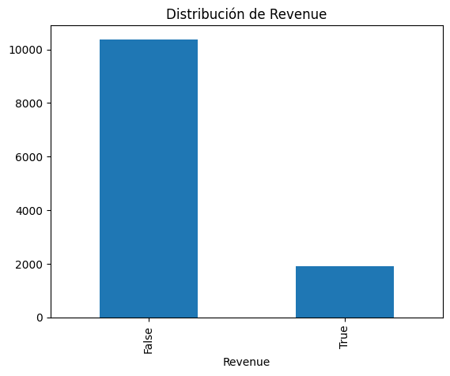

```python
df.Revenue.value_counts().plot(kind='bar', title='Distribución de Revenue')
```

```python
# Porcentaje de observaciones que terminan en ingresos respecto al total de observaciones
(df[df["Revenue"] == True].count()["Revenue"]/len(df))*100
```

```
15.533664414231051
```

Como se puede ver en el gráfico y en el cálculo del porcentaje que representa el valor "True" de Revenue, aquellos visitantes que terminan realizando una compra son muchos menos que aquellos que no terminan realizando ninguna compra. Esto puede ser un handicap a la hora de realizar un modelo que trate de predecir la probabilidad de que una visita a la web termine en compra, ya que las observaciones no están muy equilibradas. En cualquier caso, y dado que estos son los datos con los que contamos, continuaremos adelante y entrenaremos los modelos, teniendo siempre en cuenta este hecho.

```python
corr_matrix = df.select_dtypes(include=['float64']).corr()
corr_matrix
```

|  | Administrative | Administrative_Duration | Informational | Informational_Duration | ProductRelated | ProductRelated_Duration | BounceRates | ExitRates | PageValues | SpecialDay |
| --- | --- | --- | --- | --- | --- | --- | --- | --- | --- | --- |
| Administrative | 1.000000 | 0.601171 | 0.376374 | 0.255479 | 0.430116 | 0.372935 | -0.221188 | -0.314919 | 0.098267 | -0.095300 |
| Administrative_Duration | 0.601171 | 1.000000 | 0.302304 | 0.237734 | 0.288277 | 0.354749 | -0.142435 | -0.204583 | 0.067096 | -0.073636 |
| Informational | 0.376374 | 0.302304 | 1.000000 | 0.618880 | 0.373680 | 0.387065 | -0.114485 | -0.162471 | 0.048217 | -0.048448 |
| Informational_Duration | 0.255479 | 0.237734 | 0.618880 | 1.000000 | 0.279701 | 0.347088 | -0.073064 | -0.104530 | 0.030579 | -0.030731 |
| ProductRelated | 0.430116 | 0.288277 | 0.373680 | 0.279701 | 1.000000 | 0.860711 | -0.201828 | -0.290579 | 0.055521 | -0.024348 |
| ProductRelated_Duration | 0.372935 | 0.354749 | 0.387065 | 0.347088 | 0.860711 | 1.000000 | -0.181990 | -0.249958 | 0.052124 | -0.036757 |
| BounceRates | -0.221188 | -0.142435 | -0.114485 | -0.073064 | -0.201828 | -0.181990 | 1.000000 | 0.911252 | -0.118532 | 0.074726 |
| ExitRates | -0.314919 | -0.204583 | -0.162471 | -0.104530 | -0.290579 | -0.249958 | 0.911252 | 1.000000 | -0.174110 | 0.104718 |
| PageValues | 0.098267 | 0.067096 | 0.048217 | 0.030579 | 0.055521 | 0.052124 | -0.118532 | -0.174110 | 1.000000 | -0.063777 |
| SpecialDay | -0.095300 | -0.073636 | -0.048448 | -0.030731 | -0.024348 | -0.036757 | 0.074726 | 0.104718 | -0.063777 | 1.000000 |

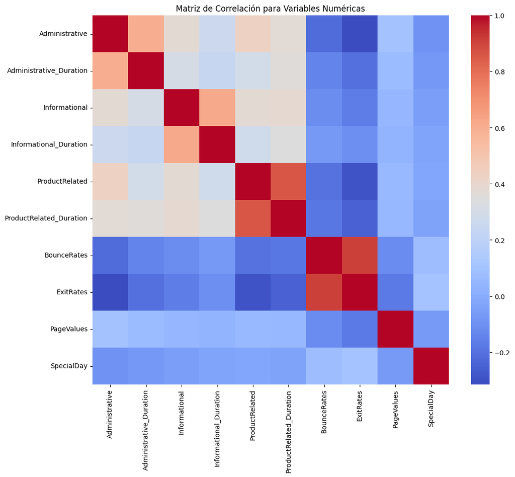

```python
plt.figure(figsize=(12, 10))
sns.heatmap(corr_matrix, cmap='coolwarm')

plt.title('Matriz de Correlación para Variables Numéricas')
plt.show()
```

En un rápido estudio de la correlación entre las variables numéricas, se puede adelantar que las variables que hacen referencia a los tipos de web y sus correspondientes duraciones están correladas de manera media en el caso de Administrative e Informational y fuerte en el caso de ProductRelated (R=0.86). Por otro lado, la correlación entre BounceRates y ExitRates es bastante fuerte (R=0.91). Como se pretende usar un modelo lineal, para mantener la hipótesis de independencia de las variables, usaremos el criterio de R>0.9 para decidir que una de estas dos variables debe ser borrada.

Análisis de los tipos de páginas y la duración en cada una de ellas:

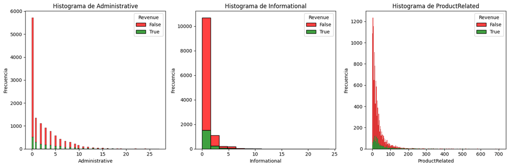

```python
var_web_type = ["Administrative", "Informational", "ProductRelated"]

histograma_facetting_revenue(var_web_type)
```

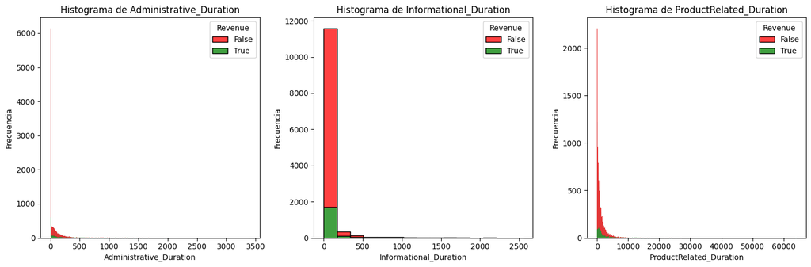

```python
histograma_facetting_revenue(var_durations)
```

De las gráficas en las líneas superiores se puede ver más claramente el fuerte sesgo a la derecha que ya se anticipaba con la información anterior. Podría parecer que aquellas observaciones que muestran valores más a la derecha en todas estas gráficas, al tener frecuencias insignificantes frente a las observaciones con valores más cercanos a 0 (acumuladas a la izquierda) podrían ser eliminadas al no aportar mucha información, pero estas observaciones podrían contener valores en otras variables que sí sirvieran para conformar grupos de muestras homogéneas.

En cualquier caso, se mostrará ahora la relación entre cada tipo de web y la duración en ellas.

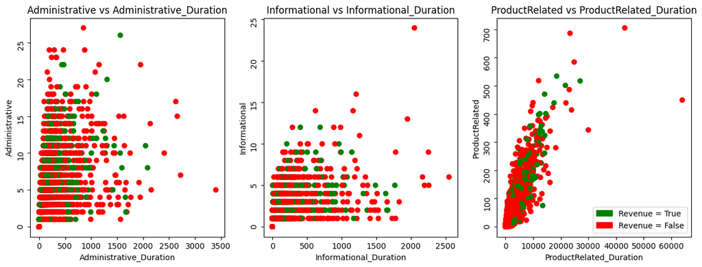

```python
fig, axes = plt.subplots(nrows=1, ncols=3, figsize=(15, 5))
axes = axes.flatten()

colors = df.Revenue.map({True: 'green', False: 'red'})

axes[0].scatter(df.Administrative_Duration, df.Administrative, c=colors)
axes[0].set_title('Administrative vs Administrative_Duration')
axes[0].set_xlabel('Administrative_Duration')
axes[0].set_ylabel('Administrative')
axes[0].tick_params(axis='y', labelrotation=90)

axes[1].scatter(df.Informational_Duration, df.Informational, c=colors)
axes[1].set_title('Informational vs Informational_Duration')
axes[1].set_xlabel('Informational_Duration')
axes[1].set_ylabel('Informational')
axes[1].tick_params(axis='y', labelrotation=90)

axes[2].scatter(df.ProductRelated_Duration, df.ProductRelated, c=colors)
axes[2].set_title('ProductRelated vs ProductRelated_Duration')
axes[2].set_xlabel('ProductRelated_Duration')
axes[2].set_ylabel('ProductRelated')
axes[2].tick_params(axis='y', labelrotation=90)

green_patch = mpatches.Patch(color='green', label='Revenue = True')
red_patch = mpatches.Patch(color='red', label='Revenue = False')
plt.legend(handles=[green_patch, red_patch])

plt.show()
```

Al poner en contraste cada tipo de web con la duración, y teniendo en cuenta el facetting por Revenue, queda claro que no existen grupos claros en ninguna de ellas, aunque sí se pueden ver ciertas relaciones entre ellas:

- En la relación Administrative vs Adminsitrative_Duration se ve que la mayoría de observaciones de concentran en las duraciones inferiores o iguales a 500 para prácticamente todos los valores de Administrative.
- En la relación Informational vs Informational_Duration no está tan clara la relación a simple vista, aunque se aprecian varios valores que parecen outliers.
- En la relación ProductRelated y PRoductRelated_Duration es donde parece verse mejor una relación lineal, de pendiente muy pronunciada, así como varios valores que claramente son outliers.

Debido a que existen otras variables, se decide no eliminar de momento los valores outliers, ya que estas observaciones poderían tener valores normales en el resto de variables y pueden servir en para entrenar el modelo.

Análisis de BounceRates, ExitRates y PageValues

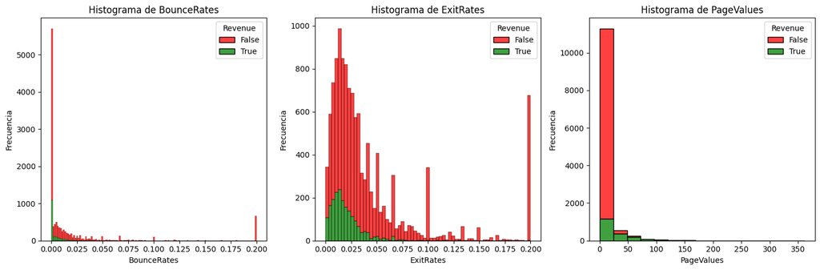

```python
var_rates = ["BounceRates", "ExitRates", "PageValues"]

histograma_facetting_revenue(var_rates)
```

```python
print(df[var_rates].describe())
```

```
        BounceRates     ExitRates    PageValues
count  12283.000000  12283.000000  12283.000000
mean       0.021723      0.042611      5.911793
std        0.047686      0.047964     18.600350
min        0.000000      0.000000      0.000000
25%        0.000000      0.014286      0.000000
50%        0.003077      0.025000      0.000000
75%        0.016667      0.050000      0.000000
max        0.200000      0.200000    361.763742
```

Se vuelven a ver fuertes sesgos a la derecha en las gráficas de BounceRates y PageValues, y, aunque en mucho menor medida también en la de ExitRates. Ésta última es la que menos sesgo tiene a tenor de la gráfica y de los datos de sus cuartiles.

Como se adelantó, las variables BounceRates y ExitRates tienen un coeficiente de correlación R mayor de 0.9. En vista de que la distribución de BounceRates tiene un sesgo bastante mayor al de ExitRates, será la primera la que eliminemos.

Análisis de SpecialDay, Month y Weekend

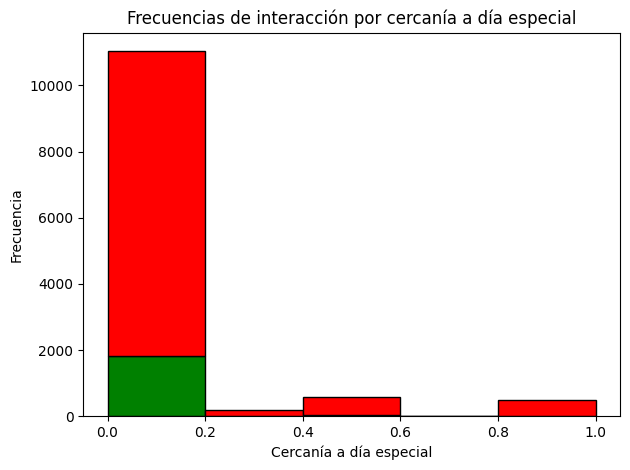

```python
revenue_true = df[df['Revenue'] == True]['SpecialDay']
revenue_false = df[df['Revenue'] == False]['SpecialDay']

histograma_specialday_revenue(revenue_true, revenue_false)
```

Como era de esperar, la mayoría de visitas se producen fuera de días cercanos a fechas especiales. Puede ser interesante analizar qué ocurre en fechas cercanas a estos días especiales, desde los días más alejados pero ya en vísperas hasta los días críticos previos a estos días especiales.

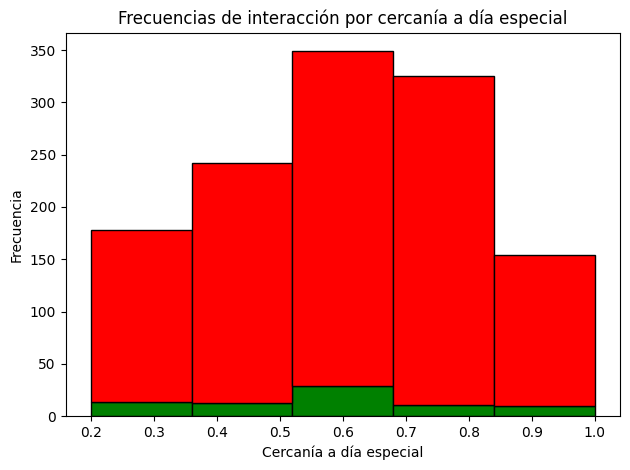

```python
revenue_true_specialday = df[(df['Revenue'] == True) & (df['SpecialDay']>0)]['SpecialDay']
revenue_false_specialday = df[(df['Revenue'] == False) & (df['SpecialDay']>0)]['SpecialDay']

histograma_specialday_revenue(revenue_true_specialday, revenue_false_specialday)
```

Se puede observar que, ante la cercanía de fechas especiales, la mayoría de visitas y compras no se producen precisamente en los días más críticos o cercanos, sino que se producen cuando aún faltan algunos días (como se ve en la distribución, que asemeja una normal con los datos acumulados en un punto medio). Es también en esos días cuando se producen el mayor número de transacciones, como se puede ver en el valor de 0.6, donde la franja verde que representa el Revenue es bastante superior al resto de barras.

```python
# Ordenamos los meses presentes en el dataset
ordered_months = ['Feb', 'Mar', 'May', 'June',
                  'Jul', 'Aug', 'Sep', 'Oct', 'Nov', 'Dec']

df['Month'] = pd.Categorical(df['Month'], categories=ordered_months, ordered=True)
comprobar_categorias(["Month"])
```

```
Month: Index(['Feb', 'Mar', 'May', 'June', 'Jul', 'Aug', 'Sep', 'Oct', 'Nov', 'Dec'], dtype='object')
```

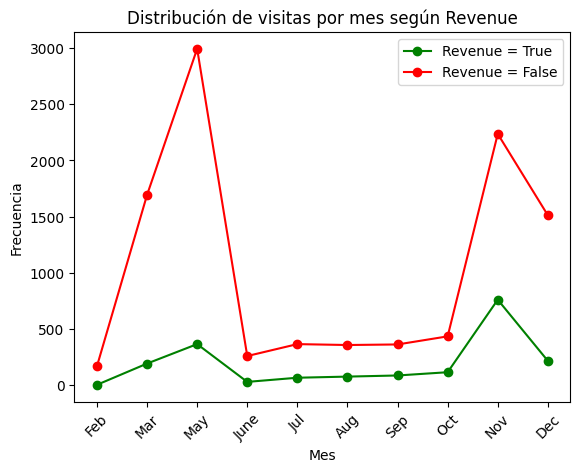

```python
month_counts_true = df[df['Revenue'] == True]['Month'].value_counts().sort_index()
month_counts_false = df[df['Revenue'] == False]['Month'].value_counts().sort_index()

plt.plot(month_counts_true.index, month_counts_true.values, marker='o', label='Revenue = True', color='green')
plt.plot(month_counts_false.index, month_counts_false.values, marker='o', label='Revenue = False', color='red')
plt.title('Distribución de visitas por mes según Revenue')
plt.xlabel('Mes')
plt.ylabel('Frecuencia')
plt.xticks(rotation=45)
plt.legend()

plt.show()
```

Se puede observar que, para todos los meses, las diferencias entre las interacciones que terminan en compra y las que no lo hacen no son tan grandes (eso sí, siempre son más numerosas las que no terminan en transacción que las que sí), a excepción de cuatro meses: marzo, mayo, noviembre y diciembre. En estos cuatro meses, las interacciones que no acaban en compra son muchísimo más numerosas que las que sí lo hacen, si bien el comportamiento de ambas es bastante parejo, subiendo ambas en los mismos meses y bajando también en los mismos momentos.

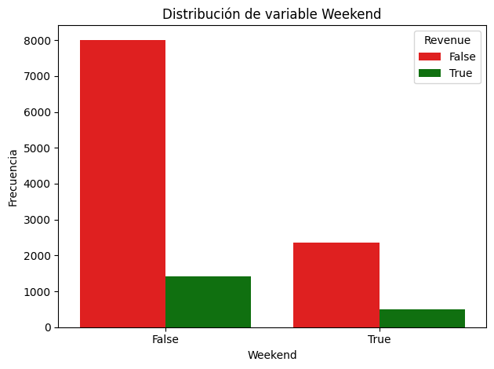

```python
sns.countplot(data=df, x='Weekend', hue='Revenue', color='black', palette={True: 'green', False: 'red'})
plt.title('Distribución de variable Weekend')
plt.xlabel('Weekend')
plt.ylabel('Frecuencia')
plt.tight_layout()
plt.show()
```

```python
weekend_t = df[df["Weekend"] == True].Weekend

perc_weekend = (weekend_t.count()/df.Weekend.count())*100
print(f"Porcentaje de visitas en fin de semana: {round(perc_weekend,2)}")
print(f"Porcentaje de visitas entre semana: {round(100-perc_weekend,2)}")
```

```
Porcentaje de visitas en fin de semana: 23.3
Porcentaje de visitas entre semana: 76.7
```

```python
weekend_t_revenue_t = df[(df['Weekend'] == True) & (df['Revenue'] == True)].shape[0]
weekend_t_revenue_f = df[(df['Weekend'] == True) & (df['Revenue'] == False)].shape[0]
weekend_f_revenue_t = df[(df['Weekend'] == False) & (df['Revenue'] == True)].shape[0]
weekend_f_revenue_f = df[(df['Weekend'] == False) & (df['Revenue'] == False)].shape[0]

print(f"Porcentaje de ingresos entre semana: {round(weekend_f_revenue_t*100/(weekend_f_revenue_t+weekend_f_revenue_f),2)}")
print(f"Porcentaje de ingresos en fin de semana: {round(weekend_t_revenue_t*100/(weekend_t_revenue_t+weekend_t_revenue_f),2)}")
```

```
Porcentaje de ingresos entre semana: 14.96
Porcentaje de ingresos en fin de semana: 17.44
```

Aunque los dos días del fin de semana representan el 28.6% del total de días de la semana, las visitas en fin de semana sólo representan un 23.3% del total de visitas, lo cual nos indica que, en terminos relativos, los fines de semana no son especialmente fuertes en cuanto a visitas.

Por otro lado, no sólo las visitas en general son mucho más numerosas entre semana que los fines de semana, sino que también lo son las visitas que terminan siendo monetizadas. En cualquier caso, en términos relativos, los fines de semana son ligeramente más rentables, ya que el 17.44% de sus visitas acaban en ingresos mientras, del total de visitas de entre semana, lo hacen el 14.96%.

Análisis de OperatingSystems, Browser, Region y TrafficType:

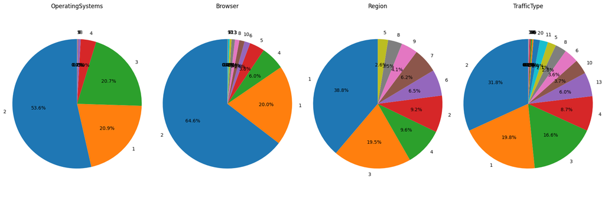

```python
var_user = ["OperatingSystems", "Browser", "Region", "TrafficType"]

diagrama_circular_frecuencias(var_user)
```

Como cada variable hace referencia a unas categorías muy distintas, los códigos de colores no importan tanto, sino lo que nos dice la distribución de los mismos.

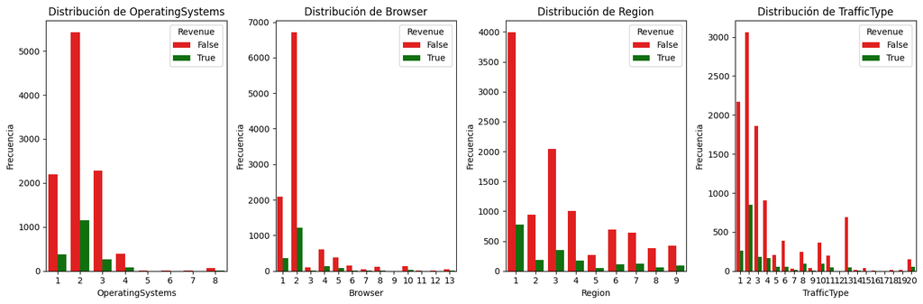

```python
barras_facetting_revenue(var_user)
```

Al estudiar la distribución de las variables relacionadas con el tipo de usuario que visita la página (Sistema operativo, navegador, región y tipo de tráfico), vemos que todas ellas tienen un fuerte sesgo hacia la derecha. Region es, quizá, la que menor sesgo tiene, pero tampoco se libra.

Como conclusión, se puede ver que los usuarios son mayoritariamente usuarios del Sistema operativo asignado al 2, y, en menor medida, al 1 y al 3; suelen utilizar el navegador asignado a la categoría 2, seguidos, muy de lejos, por los de la categoría 1; la mayoría pertenece a la región asignada a la categoría 1 de regiones, seguidos de los de la región 3 y la 4; y el tipo de tráfico mayoritario es el 2, seguido del 1 y el 3.

Poca más información se puede dar al respecto, puesto que se desconocen los significados reales de estos códigos categóricos, más allá de que representan a diferentes sistemas operativos, navegadores, regiones y tipos de tráfico.

Análisis de VisitorType

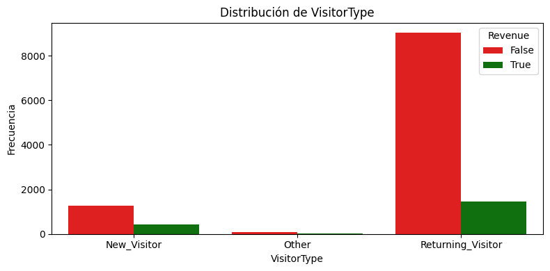

```python
barras_facetting_revenue(["VisitorType"])
```

Del diagrama de barras se puede adelantar que los visitantes que ya han estado en la web son mayoritarios, si bien, el gran número de visitas que no terminan con una compra contrasta con el número muy inferior de visitas de éstos que sí terminan en compra. En contraposición, los nuevos visitantes, mucho menos numerosos, son más propensos a realizar alguna compra en esa primera visita. Esto nos hace pensar que los nuevos visitantes visitan la página buscando algún producto concreto, es decir, toman la iniciativa de visitar la página ya que tienen una necesidad concreta, mientras que los visitantes que ya han estado antes parece que buscan novedades u ofertas y que, al no quedar satisfechos con lo que ven, no terminan comprando. Esto podría ser señal de problemas de la empresa para "sorprender" al visitante que vuelve con nuevas ofertas o nuevos productos.

Finalmente, existe la categoría de Otros, que bien podrían ser visitantes que no es posible categorizar en las otras dos categorías. En todo caso, su escaso número los hace insignificantes frente a los otros dos tipos.

Para finalizar el estudio de variables, antes de comenzar la modelización, se procederá a transformar las variables que lo necesiten para que todas sean numéricas y se pueda operar con ellas.

```python
df_num = df[var_web_type+var_durations+var_rates+["SpecialDay"]].copy()

''' Se elimina también la variable BounceRates motivado por su alta correlación con ExitRates y
su gran sesgo en la distribución'''
df_num = df_num.drop("BounceRates", axis=1)
df_num
```

|  | Administrative | Informational | ProductRelated | Administrative_Duration | Informational_Duration | ProductRelated_Duration | ExitRates | PageValues | SpecialDay |
| --- | --- | --- | --- | --- | --- | --- | --- | --- | --- |
| 0 | 0.0 | 0.0 | 1.0 | 0.0 | 0.0 | 0.000000 | 0.200000 | 0.000000 | 0.0 |
| 1 | 0.0 | 0.0 | 2.0 | 0.0 | 0.0 | 64.000000 | 0.100000 | 0.000000 | 0.0 |
| 3 | 0.0 | 0.0 | 2.0 | 0.0 | 0.0 | 2.666667 | 0.140000 | 0.000000 | 0.0 |
| 4 | 0.0 | 0.0 | 10.0 | 0.0 | 0.0 | 627.500000 | 0.050000 | 0.000000 | 0.0 |
| 5 | 0.0 | 0.0 | 19.0 | 0.0 | 0.0 | 154.216667 | 0.024561 | 0.000000 | 0.0 |
| ... | ... | ... | ... | ... | ... | ... | ... | ... | ... |
| 12325 | 3.0 | 0.0 | 53.0 | 145.0 | 0.0 | 1783.791667 | 0.029031 | 12.241717 | 0.0 |
| 12326 | 0.0 | 0.0 | 5.0 | 0.0 | 0.0 | 465.750000 | 0.021333 | 0.000000 | 0.0 |
| 12327 | 0.0 | 0.0 | 6.0 | 0.0 | 0.0 | 184.250000 | 0.086667 | 0.000000 | 0.0 |
| 12328 | 4.0 | 0.0 | 15.0 | 75.0 | 0.0 | 346.000000 | 0.021053 | 0.000000 | 0.0 |
| 12329 | 0.0 | 0.0 | 3.0 | 0.0 | 0.0 | 21.250000 | 0.066667 | 0.000000 | 0.0 |

12283 rows × 9 columns

```python
# Convertimos las variables boolean a unos y ceros
df_num[["Weekend", "Revenue"]] = df[["Weekend", "Revenue"]].astype(int)
df_num
```

|  | Administrative | Informational | ProductRelated | Administrative_Duration | Informational_Duration | ProductRelated_Duration | ExitRates | PageValues | SpecialDay | Weekend | Revenue |
| --- | --- | --- | --- | --- | --- | --- | --- | --- | --- | --- | --- |
| 0 | 0.0 | 0.0 | 1.0 | 0.0 | 0.0 | 0.000000 | 0.200000 | 0.000000 | 0.0 | 0 | 0 |
| 1 | 0.0 | 0.0 | 2.0 | 0.0 | 0.0 | 64.000000 | 0.100000 | 0.000000 | 0.0 | 0 | 0 |
| 3 | 0.0 | 0.0 | 2.0 | 0.0 | 0.0 | 2.666667 | 0.140000 | 0.000000 | 0.0 | 0 | 0 |
| 4 | 0.0 | 0.0 | 10.0 | 0.0 | 0.0 | 627.500000 | 0.050000 | 0.000000 | 0.0 | 1 | 0 |
| 5 | 0.0 | 0.0 | 19.0 | 0.0 | 0.0 | 154.216667 | 0.024561 | 0.000000 | 0.0 | 0 | 0 |
| ... | ... | ... | ... | ... | ... | ... | ... | ... | ... | ... | ... |
| 12325 | 3.0 | 0.0 | 53.0 | 145.0 | 0.0 | 1783.791667 | 0.029031 | 12.241717 | 0.0 | 1 | 0 |
| 12326 | 0.0 | 0.0 | 5.0 | 0.0 | 0.0 | 465.750000 | 0.021333 | 0.000000 | 0.0 | 1 | 0 |
| 12327 | 0.0 | 0.0 | 6.0 | 0.0 | 0.0 | 184.250000 | 0.086667 | 0.000000 | 0.0 | 1 | 0 |
| 12328 | 4.0 | 0.0 | 15.0 | 75.0 | 0.0 | 346.000000 | 0.021053 | 0.000000 | 0.0 | 0 | 0 |
| 12329 | 0.0 | 0.0 | 3.0 | 0.0 | 0.0 | 21.250000 | 0.066667 | 0.000000 | 0.0 | 1 | 0 |

12283 rows × 11 columns

```python
'''Para las variables Month y VisitorType, ya que se conoce el valor real de sus categorías,
se realizará una codificación One-hot encoder'''

df_month_encoded = pd.get_dummies(df['Month'])
df_type_encoded = pd.get_dummies(df['VisitorType'])

df_num = pd.concat([df_num, df_month_encoded.astype(int), df_type_encoded.astype(int)], axis=1)
df_num
```

|  | Administrative | Informational | ProductRelated | Administrative_Duration | Informational_Duration | ProductRelated_Duration | ExitRates | PageValues | SpecialDay | Weekend | ... | June | Jul | Aug | Sep | Oct | Nov | Dec | New_Visitor | Other | Returning_Visitor |
| --- | --- | --- | --- | --- | --- | --- | --- | --- | --- | --- | --- | --- | --- | --- | --- | --- | --- | --- | --- | --- | --- |
| 0 | 0.0 | 0.0 | 1.0 | 0.0 | 0.0 | 0.000000 | 0.200000 | 0.000000 | 0.0 | 0 | ... | 0 | 0 | 0 | 0 | 0 | 0 | 0 | 0 | 0 | 1 |
| 1 | 0.0 | 0.0 | 2.0 | 0.0 | 0.0 | 64.000000 | 0.100000 | 0.000000 | 0.0 | 0 | ... | 0 | 0 | 0 | 0 | 0 | 0 | 0 | 0 | 0 | 1 |
| 3 | 0.0 | 0.0 | 2.0 | 0.0 | 0.0 | 2.666667 | 0.140000 | 0.000000 | 0.0 | 0 | ... | 0 | 0 | 0 | 0 | 0 | 0 | 0 | 0 | 0 | 1 |
| 4 | 0.0 | 0.0 | 10.0 | 0.0 | 0.0 | 627.500000 | 0.050000 | 0.000000 | 0.0 | 1 | ... | 0 | 0 | 0 | 0 | 0 | 0 | 0 | 0 | 0 | 1 |
| 5 | 0.0 | 0.0 | 19.0 | 0.0 | 0.0 | 154.216667 | 0.024561 | 0.000000 | 0.0 | 0 | ... | 0 | 0 | 0 | 0 | 0 | 0 | 0 | 0 | 0 | 1 |
| ... | ... | ... | ... | ... | ... | ... | ... | ... | ... | ... | ... | ... | ... | ... | ... | ... | ... | ... | ... | ... | ... |
| 12325 | 3.0 | 0.0 | 53.0 | 145.0 | 0.0 | 1783.791667 | 0.029031 | 12.241717 | 0.0 | 1 | ... | 0 | 0 | 0 | 0 | 0 | 0 | 1 | 0 | 0 | 1 |
| 12326 | 0.0 | 0.0 | 5.0 | 0.0 | 0.0 | 465.750000 | 0.021333 | 0.000000 | 0.0 | 1 | ... | 0 | 0 | 0 | 0 | 0 | 1 | 0 | 0 | 0 | 1 |
| 12327 | 0.0 | 0.0 | 6.0 | 0.0 | 0.0 | 184.250000 | 0.086667 | 0.000000 | 0.0 | 1 | ... | 0 | 0 | 0 | 0 | 0 | 1 | 0 | 0 | 0 | 1 |
| 12328 | 4.0 | 0.0 | 15.0 | 75.0 | 0.0 | 346.000000 | 0.021053 | 0.000000 | 0.0 | 0 | ... | 0 | 0 | 0 | 0 | 0 | 1 | 0 | 0 | 0 | 1 |
| 12329 | 0.0 | 0.0 | 3.0 | 0.0 | 0.0 | 21.250000 | 0.066667 | 0.000000 | 0.0 | 1 | ... | 0 | 0 | 0 | 0 | 0 | 1 | 0 | 1 | 0 | 0 |

12283 rows × 24 columns

```python
''' Finalmente, para el resto de variables categóricas, ya que desconocemos el verdadero significado de cada categoría,
se procederá a realizar otro tipo de encoding que nos evitará tener multitud de variables: frecuency encoding. Se
asignará a cada muestra el valor de la frecuencia para cada una de estas variables, de forma que se primarán las más
frecuentes y se penalizarán las menos.'''

var_frec_enc = ['OperatingSystems','Browser','Region','TrafficType']

for var in var_frec_enc:
    freq_encoding = df[var].value_counts()

    df_num[f'{var}_freq'] = df[var].map(freq_encoding)
```

Ahora que todas las variables son numéricas, podemos proceder a realizar un algoritmo de detección de anomalías que nos diga si existen datos outliers y cuáles son. Se realizará un *Local Outlier Factor*.

```python
# Separamos las variables predictoras de la variable target
x = df_num.drop('Revenue', axis=1)
y = df_num['Revenue']

clf = LocalOutlierFactor(n_neighbors=20, contamination="auto")
y_pred = clf.fit_predict(x)
outliers_indices = [i for i, val in enumerate(y_pred) if val == -1]
outliers = df_num[y_pred == -1]
n_outliers = sum(y_pred==-1)
n_total = len(y_pred)
x_scores = clf.negative_outlier_factor_
radius = (x_scores.max() - x_scores) / (x_scores.max() - x_scores.min())
print(f"El número de outliers es de {n_outliers} de {n_total}")
```

```
El número de outliers es de 815 de 12283
```

```python
outliers
```

|  | Administrative | Informational | ProductRelated | Administrative_Duration | Informational_Duration | ProductRelated_Duration | ExitRates | PageValues | SpecialDay | Weekend | ... | Oct | Nov | Dec | New_Visitor | Other | Returning_Visitor | OperatingSystems_freq | Browser_freq | Region_freq | TrafficType_freq |
| --- | --- | --- | --- | --- | --- | --- | --- | --- | --- | --- | --- | --- | --- | --- | --- | --- | --- | --- | --- | --- | --- |
| 54 | 0.0 | 0.0 | 4.0 | 0.000000 | 0.000000 | 135.666667 | 0.025000 | 0.000000 | 0.4 | 0 | ... | 0 | 0 | 0 | 0 | 0 | 1 | 2545 | 104 | 4765 | 1067 |
| 60 | 0.0 | 0.0 | 6.0 | 0.000000 | 0.000000 | 169.000000 | 0.016667 | 0.000000 | 0.4 | 0 | ... | 0 | 0 | 0 | 0 | 0 | 1 | 2573 | 2451 | 2394 | 2036 |
| 184 | 0.0 | 16.0 | 5.0 | 0.000000 | 1210.397619 | 279.857143 | 0.012764 | 0.000000 | 0.0 | 0 | ... | 0 | 0 | 0 | 0 | 0 | 1 | 6578 | 7934 | 4765 | 343 |
| 191 | 3.0 | 5.0 | 24.0 | 1226.000000 | 3.000000 | 3230.250000 | 0.096000 | 0.000000 | 0.0 | 0 | ... | 0 | 0 | 0 | 0 | 0 | 1 | 6578 | 7934 | 4765 | 3907 |
| 214 | 2.0 | 3.0 | 10.0 | 2.000000 | 261.000000 | 281.000000 | 0.042857 | 0.000000 | 0.0 | 0 | ... | 0 | 0 | 0 | 0 | 0 | 1 | 6578 | 7934 | 4765 | 3907 |
| ... | ... | ... | ... | ... | ... | ... | ... | ... | ... | ... | ... | ... | ... | ... | ... | ... | ... | ... | ... | ... | ... |
| 12236 | 12.0 | 4.0 | 107.0 | 219.274359 | 857.166667 | 2640.135697 | 0.015490 | 6.479206 | 0.0 | 1 | ... | 0 | 1 | 0 | 0 | 0 | 1 | 2573 | 7934 | 4765 | 3907 |
| 12242 | 6.0 | 0.0 | 8.0 | 243.750000 | 0.000000 | 171.250000 | 0.067222 | 0.000000 | 0.0 | 0 | ... | 0 | 0 | 1 | 0 | 0 | 1 | 2545 | 7934 | 2394 | 2435 |
| 12259 | 4.0 | 0.0 | 2.0 | 91.000000 | 0.000000 | 22.000000 | 0.022222 | 0.000000 | 0.0 | 0 | ... | 0 | 0 | 1 | 1 | 0 | 0 | 2573 | 2451 | 4765 | 3907 |
| 12307 | 2.0 | 3.0 | 27.0 | 305.125000 | 368.250000 | 1121.250000 | 0.042857 | 39.519807 | 0.0 | 0 | ... | 0 | 0 | 1 | 0 | 0 | 1 | 2545 | 7934 | 4765 | 3907 |
| 12314 | 0.0 | 0.0 | 7.0 | 0.000000 | 0.000000 | 705.833333 | 0.085714 | 0.000000 | 0.0 | 1 | ... | 0 | 0 | 1 | 0 | 0 | 1 | 6 | 6 | 1175 | 2435 |

815 rows × 28 columns

Dado que se entrenará un modelo de regresión logística más adelante, y estos son muy sensibles a valores outliers, éstos serán eliminados de nuestra dataset.

```python
'''Reseteamos los índices ya que, al eliminar anteriormente algunas observaciones,
no coinciden el índice con la posición de cada observación restante'''
x = x.reset_index(drop=True)
y = y.reset_index(drop=True)

# Eliminamos los outliers por índice
x = x[~x.index.isin(outliers_indices)]
y = y[~y.index.isin(outliers_indices)]
```

```python
print(len(x))
print(len(y))
```

```
11468
11468
```

A continuación, se procederá a estandarizar las variables que lo necesitan para uniformizar las escalas y facilitar los cálculos posteriores.

```python
x = standard_dataset(x)

x
```

|  | Administrative | Informational | ProductRelated | Administrative_Duration | Informational_Duration | ProductRelated_Duration | ExitRates | PageValues | SpecialDay | Weekend | ... | Oct | Nov | Dec | New_Visitor | Other | Returning_Visitor | OperatingSystems_freq | Browser_freq | Region_freq | TrafficType_freq |
| --- | --- | --- | --- | --- | --- | --- | --- | --- | --- | --- | --- | --- | --- | --- | --- | --- | --- | --- | --- | --- | --- |
| 0 | -0.680394 | -0.384508 | -0.723554 | -0.535807 | -0.240122 | -0.699073 | 3.215215 | -0.327767 | -0.313999 | -0.550619 | ... | -0.212841 | -0.569295 | -0.401203 | -0.398416 | -0.0755 | 0.407916 | -0.951353 | -1.040627 | 1.214231 | 0.152907 |
| 1 | -0.680394 | -0.384508 | -0.700019 | -0.535807 | -0.240122 | -0.661395 | 1.163905 | -0.327767 | -0.313999 | -0.550619 | ... | -0.212841 | -0.569295 | -0.401203 | -0.398416 | -0.0755 | 0.407916 | 0.909851 | 0.727467 | 1.214231 | 1.257950 |
| 2 | -0.680394 | -0.384508 | -0.700019 | -0.535807 | -0.240122 | -0.697503 | 1.984429 | -0.327767 | -0.313999 | -0.550619 | ... | -0.212841 | -0.569295 | -0.401203 | -0.398416 | -0.0755 | 0.407916 | -0.964365 | 0.727467 | -0.851521 | -0.874062 |
| 3 | -0.680394 | -0.384508 | -0.511740 | -0.535807 | -0.240122 | -0.329647 | 0.138251 | -0.327767 | -0.313999 | 1.816136 | ... | -0.212841 | -0.569295 | -0.401203 | -0.398416 | -0.0755 | 0.407916 | -0.964365 | -1.797461 | 1.214231 | -0.874062 |
| 4 | -0.680394 | -0.384508 | -0.299926 | -0.535807 | -0.240122 | -0.608282 | -0.383574 | -0.327767 | -0.313999 | -0.550619 | ... | -0.212841 | -0.569295 | -0.401203 | -0.398416 | -0.0755 | 0.407916 | 0.909851 | 0.727467 | 1.214231 | -0.146626 |
| ... | ... | ... | ... | ... | ... | ... | ... | ... | ... | ... | ... | ... | ... | ... | ... | ... | ... | ... | ... | ... | ... |
| 12278 | 0.259698 | -0.384508 | 0.500260 | 0.682662 | -0.240122 | 0.351094 | -0.291896 | 0.384698 | -0.313999 | 1.816136 | ... | -0.212841 | -0.569295 | 2.492504 | -0.398416 | -0.0755 | 0.407916 | -1.925872 | -1.774888 | 1.214231 | 0.152907 |
| 12279 | -0.680394 | -0.384508 | -0.629414 | -0.535807 | -0.240122 | -0.424874 | -0.449791 | -0.327767 | -0.313999 | 1.816136 | ... | -0.212841 | 1.756559 | -0.401203 | -0.398416 | -0.0755 | 0.407916 | -0.964365 | 0.727467 | 1.214231 | -1.417575 |
| 12280 | -0.680394 | -0.384508 | -0.605879 | -0.535807 | -0.240122 | -0.590600 | 0.890397 | -0.327767 | -0.313999 | 1.816136 | ... | -0.212841 | 1.756559 | -0.401203 | -0.398416 | -0.0755 | 0.407916 | -0.964365 | 0.727467 | 1.214231 | -1.122546 |
| 12281 | 0.573062 | -0.384508 | -0.394066 | 0.094436 | -0.240122 | -0.495374 | -0.455549 | -0.327767 | -0.313999 | -0.550619 | ... | -0.212841 | 1.756559 | -0.401203 | -0.398416 | -0.0755 | 0.407916 | 0.909851 | 0.727467 | -0.133196 | -1.489643 |
| 12282 | -0.680394 | -0.384508 | -0.676484 | -0.535807 | -0.240122 | -0.686563 | 0.480136 | -0.327767 | -0.313999 | 1.816136 | ... | -0.212841 | 1.756559 | -0.401203 | 2.509942 | -0.0755 | -2.451485 | -0.964365 | 0.727467 | 1.214231 | 1.257950 |

11468 rows × 27 columns

```python
print(x.describe())
```

```
       Administrative  Informational  ProductRelated  Administrative_Duration  \
count    1.146800e+04   1.146800e+04    11468.000000             1.146800e+04
mean    -3.345772e-17  -9.913397e-18        0.000000             8.922057e-17
std      1.000044e+00   1.000044e+00        1.000044             1.000044e+00
min     -6.803945e-01  -3.845077e-01       -0.747089            -5.358068e-01
25%     -6.803945e-01  -3.845077e-01       -0.582345            -5.358068e-01
50%     -3.670305e-01  -3.845077e-01       -0.323461            -5.021939e-01
75%      2.596975e-01  -3.845077e-01        0.147237             1.583001e-01
max      7.467070e+00   1.175103e+01       11.820535             1.315586e+01

       Informational_Duration  ProductRelated_Duration     ExitRates  \
count            1.146800e+04             1.146800e+04  1.146800e+04
mean            -3.221854e-17            -9.913397e-18  1.313525e-16
std              1.000044e+00             1.000044e+00  1.000044e+00
min             -2.401215e-01            -6.990734e-01 -8.874039e-01
25%             -2.401215e-01            -5.875831e-01 -5.943598e-01
50%             -2.401215e-01            -3.449970e-01 -3.686613e-01
75%             -2.401215e-01             1.718730e-01  1.382507e-01
max              2.292726e+01             1.019482e+01  3.215215e+00

         PageValues    SpecialDay       Weekend  ...           Oct  \
count  1.146800e+04  11468.000000  1.146800e+04  ...  1.146800e+04
mean  -2.726184e-17      0.000000 -6.691543e-17  ... -6.939378e-17
std    1.000044e+00      1.000044  1.000044e+00  ...  1.000044e+00
min   -3.277666e-01     -0.313999 -5.506195e-01  ... -2.128409e-01
25%   -3.277666e-01     -0.313999 -5.506195e-01  ... -2.128409e-01
50%   -3.277666e-01     -0.313999 -5.506195e-01  ... -2.128409e-01
75%   -3.277666e-01     -0.313999 -5.506195e-01  ... -2.128409e-01
max    1.543183e+01      4.624201  1.816136e+00  ...  4.698345e+00

                Nov           Dec   New_Visitor         Other  \
count  11468.000000  11468.000000  1.146800e+04  1.146800e+04
mean       0.000000      0.000000 -9.913397e-18  1.487010e-17
std        1.000044      1.000044  1.000044e+00  1.000044e+00
min       -0.569295     -0.401203 -3.984156e-01 -7.550003e-02
25%       -0.569295     -0.401203 -3.984156e-01 -7.550003e-02
50%       -0.569295     -0.401203 -3.984156e-01 -7.550003e-02
75%       -0.569295     -0.401203 -3.984156e-01 -7.550003e-02
max        1.756559      2.492504  2.509942e+00  1.324503e+01

       Returning_Visitor  OperatingSystems_freq  Browser_freq   Region_freq  \
count       1.146800e+04           1.146800e+04  1.146800e+04  1.146800e+04
mean        1.288742e-16           4.956699e-18  8.922057e-17 -2.478349e-17
std         1.000044e+00           1.000044e+00  1.000044e+00  1.000044e+00
min        -2.451485e+00          -2.144290e+00 -1.830675e+00 -1.314681e+00
25%         4.079160e-01          -9.643655e-01 -1.040627e+00 -8.515209e-01
50%         4.079160e-01           9.098515e-01  7.274674e-01 -1.331961e-01
75%         4.079160e-01           9.098515e-01  7.274674e-01  1.214231e+00
max         4.079160e-01           9.098515e-01  7.274674e-01  1.214231e+00

       TrafficType_freq
count      1.146800e+04
mean       5.948038e-17
std        1.000044e+00
min       -1.674317e+00
25%       -8.740618e-01
50%        1.529071e-01
75%        1.257950e+00
max        1.257950e+00

[8 rows x 27 columns]
```

```python
corr_matrix_num = x.corr()
corr_matrix_num
```

|  | Administrative | Informational | ProductRelated | Administrative_Duration | Informational_Duration | ProductRelated_Duration | ExitRates | PageValues | SpecialDay | Weekend | ... | Oct | Nov | Dec | New_Visitor | Other | Returning_Visitor | OperatingSystems_freq | Browser_freq | Region_freq | TrafficType_freq |
| --- | --- | --- | --- | --- | --- | --- | --- | --- | --- | --- | --- | --- | --- | --- | --- | --- | --- | --- | --- | --- | --- |
| Administrative | 1.000000 | 0.381388 | 0.445783 | 0.713439 | 0.288017 | 0.402486 | -0.313796 | 0.114298 | -0.089204 | 0.027103 | ... | 0.089361 | 0.055246 | -0.019238 | 0.033612 | -0.021887 | -0.028348 | 0.015170 | 0.041894 | -0.019876 | 0.060056 |
| Informational | 0.381388 | 1.000000 | 0.387462 | 0.334085 | 0.634332 | 0.400351 | -0.162003 | 0.062605 | -0.048770 | 0.035515 | ... | 0.002056 | 0.075220 | 0.002123 | -0.055369 | -0.023996 | 0.059588 | -0.007209 | 0.031764 | 0.016984 | 0.077726 |
| ProductRelated | 0.445783 | 0.387462 | 1.000000 | 0.342532 | 0.327292 | 0.871002 | -0.305829 | 0.062282 | -0.022000 | 0.016530 | ... | 0.014264 | 0.189456 | -0.037210 | -0.127177 | -0.044814 | 0.134656 | 0.122385 | 0.095756 | 0.045335 | 0.104417 |
| Administrative_Duration | 0.713439 | 0.334085 | 0.342532 | 1.000000 | 0.258058 | 0.363806 | -0.251602 | 0.104260 | -0.075474 | 0.019651 | ... | 0.076421 | 0.049523 | -0.011349 | 0.030906 | -0.024286 | -0.025173 | -0.038593 | 0.012037 | -0.031660 | 0.044180 |
| Informational_Duration | 0.288017 | 0.634332 | 0.327292 | 0.258058 | 1.000000 | 0.373946 | -0.112394 | 0.046333 | -0.028064 | 0.011242 | ... | 0.004612 | 0.047277 | 0.003386 | -0.046544 | -0.017760 | 0.049573 | 0.010659 | 0.016107 | -0.000933 | 0.059195 |
| ProductRelated_Duration | 0.402486 | 0.400351 | 0.871002 | 0.363806 | 0.373946 | 1.000000 | -0.282309 | 0.070694 | -0.037078 | 0.009803 | ... | -0.003422 | 0.191573 | -0.028583 | -0.127608 | -0.043119 | 0.134716 | 0.127654 | 0.091352 | 0.037806 | 0.103177 |
| ExitRates | -0.313796 | -0.162003 | -0.305829 | -0.251602 | -0.112394 | -0.282309 | 1.000000 | -0.178140 | 0.103078 | -0.061422 | ... | -0.062853 | -0.058048 | -0.008412 | -0.182988 | 0.054617 | 0.168183 | -0.086439 | -0.023533 | 0.005226 | -0.143083 |
| PageValues | 0.114298 | 0.062605 | 0.062282 | 0.104260 | 0.046333 | 0.070694 | -0.178140 | 1.000000 | -0.065484 | 0.018899 | ... | 0.037319 | 0.037410 | 0.014245 | 0.105874 | 0.026845 | -0.109855 | 0.043181 | -0.021730 | -0.008595 | 0.031907 |
| SpecialDay | -0.089204 | -0.048770 | -0.022000 | -0.075474 | -0.028064 | -0.037078 | 0.103078 | -0.065484 | 1.000000 | -0.014111 | ... | -0.066832 | -0.178758 | -0.125977 | -0.085026 | -0.023707 | 0.088684 | 0.013702 | 0.012826 | 0.007704 | -0.093919 |
| Weekend | 0.027103 | 0.035515 | 0.016530 | 0.019651 | 0.011242 | 0.009803 | -0.061422 | 0.018899 | -0.014111 | 1.000000 | ... | 0.015583 | 0.038861 | -0.021445 | 0.047724 | -0.027826 | -0.040948 | -0.111150 | -0.019421 | -0.013223 | -0.002050 |
| Feb | -0.060761 | -0.036988 | -0.056710 | -0.046650 | -0.026106 | -0.048702 | 0.054786 | -0.033186 | 0.106686 | -0.024522 | ... | -0.026030 | -0.069624 | -0.049067 | -0.046621 | -0.009234 | 0.047819 | -0.018517 | -0.058606 | 0.028224 | -0.004466 |
| Mar | -0.056816 | -0.040330 | -0.118116 | -0.046188 | -0.021255 | -0.093072 | 0.010028 | -0.043803 | -0.133202 | 0.024167 | ... | -0.090290 | -0.241502 | -0.170196 | -0.022993 | -0.032028 | 0.029481 | 0.019992 | -0.009492 | 0.014098 | 0.050955 |
| May | -0.064116 | -0.037877 | -0.073211 | -0.046764 | -0.021567 | -0.072833 | 0.075595 | -0.010038 | 0.468186 | -0.030030 | ... | -0.131753 | -0.352405 | -0.248353 | -0.080591 | -0.046736 | 0.089267 | 0.034945 | 0.001069 | -0.024201 | -0.164340 |
| June | 0.005577 | 0.012131 | 0.015068 | -0.009097 | -0.008150 | -0.000065 | 0.049623 | -0.019526 | -0.049492 | -0.026403 | ... | -0.033548 | -0.089731 | -0.063237 | -0.013329 | -0.011900 | 0.015659 | 0.008128 | 0.010046 | -0.013054 | -0.014011 |
| Jul | 0.010830 | -0.003597 | 0.020275 | -0.010951 | 0.002033 | -0.003268 | 0.006976 | -0.018537 | -0.059925 | 0.002514 | ... | -0.040619 | -0.108646 | -0.076567 | -0.007171 | -0.014409 | 0.010144 | -0.005790 | -0.002659 | -0.022275 | -0.035799 |
| Aug | 0.044166 | 0.003904 | 0.022760 | 0.037848 | 0.003696 | 0.002685 | -0.018108 | 0.002804 | -0.059538 | -0.000669 | ... | -0.040357 | -0.107946 | -0.076073 | 0.017289 | -0.014316 | -0.013925 | 0.003226 | -0.008589 | -0.008812 | -0.023854 |
| Sep | 0.055625 | 0.002705 | 0.001873 | 0.036584 | -0.009782 | 0.001375 | -0.048931 | 0.008373 | -0.059693 | -0.005690 | ... | -0.040462 | -0.108226 | -0.076271 | 0.061101 | -0.014353 | -0.056991 | 0.008837 | 0.003238 | -0.025430 | 0.003623 |
| Oct | 0.089361 | 0.002056 | 0.014264 | 0.076421 | 0.004612 | -0.003422 | -0.062853 | 0.037319 | -0.066832 | 0.015583 | ... | 1.000000 | -0.121169 | -0.085392 | 0.060925 | -0.016069 | -0.056450 | -0.008051 | -0.018762 | 0.000094 | 0.016911 |
| Nov | 0.055246 | 0.075220 | 0.189456 | 0.049523 | 0.047277 | 0.191573 | -0.058048 | 0.037410 | -0.178758 | 0.038861 | ... | -0.121169 | 1.000000 | -0.228403 | 0.004996 | 0.008348 | -0.006704 | -0.026281 | 0.039004 | 0.052198 | 0.067147 |
| Dec | -0.019238 | 0.002123 | -0.037210 | -0.011349 | 0.003386 | -0.028583 | -0.008412 | 0.014245 | -0.125977 | -0.021445 | ... | -0.085392 | -0.228403 | 1.000000 | 0.070587 | 0.124322 | -0.096086 | -0.029087 | -0.008771 | -0.022317 | 0.103889 |
| New_Visitor | 0.033612 | -0.055369 | -0.127177 | 0.030906 | -0.046544 | -0.127608 | -0.182988 | 0.105874 | -0.085026 | 0.047724 | ... | 0.060925 | 0.004996 | 0.070587 | 1.000000 | -0.030080 | -0.976710 | 0.006109 | -0.033719 | -0.006571 | 0.082054 |
| Other | -0.021887 | -0.023996 | -0.044814 | -0.024286 | -0.017760 | -0.043119 | 0.054617 | 0.026845 | -0.023707 | -0.027826 | ... | -0.016069 | 0.008348 | 0.124322 | -0.030080 | 1.000000 | -0.185087 | -0.090147 | -0.071463 | -0.054658 | -0.059785 |
| Returning_Visitor | -0.028348 | 0.059588 | 0.134656 | -0.025173 | 0.049573 | 0.134716 | 0.168183 | -0.109855 | 0.088684 | -0.040948 | ... | -0.056450 | -0.006704 | -0.096086 | -0.976710 | -0.185087 | 1.000000 | 0.013345 | 0.048492 | 0.018194 | -0.067839 |
| OperatingSystems_freq | 0.015170 | -0.007209 | 0.122385 | -0.038593 | 0.010659 | 0.127654 | -0.086439 | 0.043181 | 0.013702 | -0.111150 | ... | -0.008051 | -0.026281 | -0.029087 | 0.006109 | -0.090147 | 0.013345 | 1.000000 | 0.167680 | -0.036769 | 0.069964 |
| Browser_freq | 0.041894 | 0.031764 | 0.095756 | 0.012037 | 0.016107 | 0.091352 | -0.023533 | -0.021730 | 0.012826 | -0.019421 | ... | -0.018762 | 0.039004 | -0.008771 | -0.033719 | -0.071463 | 0.048492 | 0.167680 | 1.000000 | -0.013777 | -0.020228 |
| Region_freq | -0.019876 | 0.016984 | 0.045335 | -0.031660 | -0.000933 | 0.037806 | 0.005226 | -0.008595 | 0.007704 | -0.013223 | ... | 0.000094 | 0.052198 | -0.022317 | -0.006571 | -0.054658 | 0.018194 | -0.036769 | -0.013777 | 1.000000 | 0.002056 |
| TrafficType_freq | 0.060056 | 0.077726 | 0.104417 | 0.044180 | 0.059195 | 0.103177 | -0.143083 | 0.031907 | -0.093919 | -0.002050 | ... | 0.016911 | 0.067147 | 0.103889 | 0.082054 | -0.059785 | -0.067839 | 0.069964 | -0.020228 | 0.002056 | 1.000000 |

27 rows × 27 columns

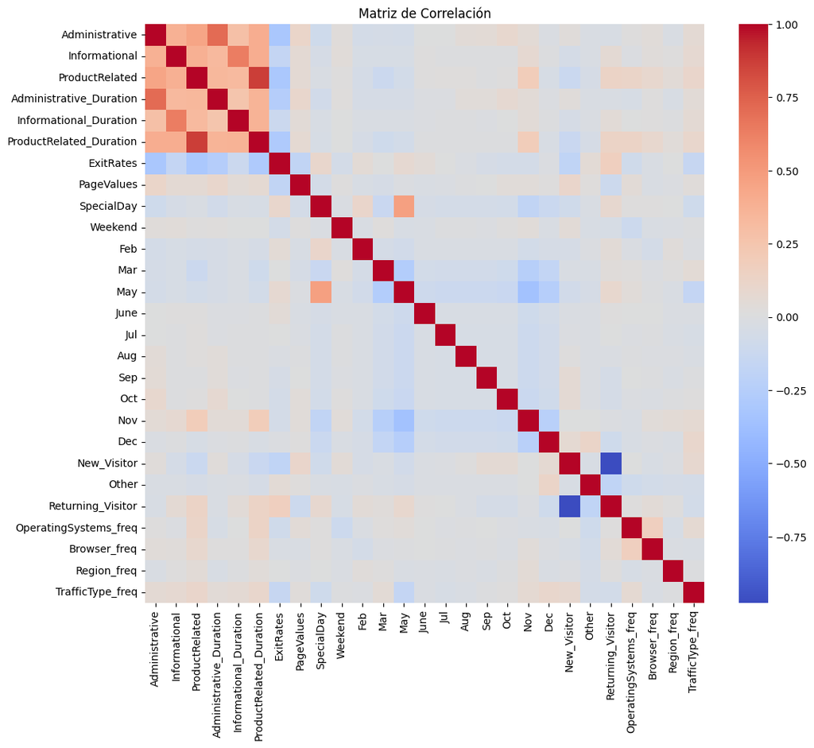

```python
plt.figure(figsize=(12, 10))
sns.heatmap(corr_matrix_num, cmap='coolwarm')

plt.title('Matriz de Correlación')
plt.show()
```

Ahora se procederá a realizar un estudio para saber si es posible reducir el número de variables. En primer lugar, se realizará un análisis de aprendizaje no supervisado, eligiendo PCA en lugar de análisis factorial ya que para éste segundo la correlación entre las variables es más importante que para PCA (el cual se beneficia de esta correlación pero también puede obtener buenos resultados ante la no correlación). Además, PCA necesita de datos estandarizados, algo que ya tenemos hecho.

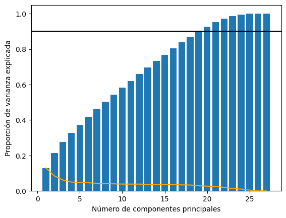

```python
pca = PCA()
pca.fit(x)

plt.plot(range(1, len(x.columns)+1), pca.explained_variance_ratio_, c="orange")
plt.bar(range(1, len(x.columns)+1), np.cumsum(pca.explained_variance_ratio_))
plt.xlabel("Número de componentes principales")
plt.ylabel("Proporción de varianza explicada")
plt.axhline(0.9, c="black")
plt.show()
```

```python
pca = PCA(n_components=20)
pca.fit(x)
comp_principales = pca.transform(x)

x_pca = pd.DataFrame(data=comp_principales, columns=[f'PC{i+1}' for i in range(20)])
x_pca
```

|  | PC1 | PC2 | PC3 | PC4 | PC5 | PC6 | PC7 | PC8 | PC9 | PC10 | PC11 | PC12 | PC13 | PC14 | PC15 | PC16 | PC17 | PC18 | PC19 | PC20 |
| --- | --- | --- | --- | --- | --- | --- | --- | --- | --- | --- | --- | --- | --- | --- | --- | --- | --- | --- | --- | --- |
| 0 | -2.589445 | 1.453081 | -1.020454 | -1.832887 | 1.381644 | -0.524609 | 1.491027 | 2.445076 | 5.732089 | 0.538974 | 1.310534 | 0.139853 | -1.774877 | 0.921835 | -1.951943 | -1.497276 | -2.624634 | -1.468709 | 0.084728 | 0.515219 |
| 1 | -1.750816 | 1.070614 | -0.955130 | 0.277945 | 0.266999 | 0.460160 | 1.523717 | 2.763473 | 5.407834 | 0.736869 | 1.287197 | 0.256952 | -1.617731 | 1.038698 | -2.342481 | -1.752254 | -3.137640 | -1.498677 | 0.973883 | 0.722734 |
| 2 | -2.297229 | 1.406664 | -0.621181 | -1.288725 | 0.817347 | -0.183355 | 0.390070 | 1.646681 | 4.681008 | 0.566833 | 1.451208 | -0.051170 | -1.747619 | 1.270455 | -3.344293 | -2.089691 | -3.432972 | -1.901042 | -0.289000 | -0.821086 |
| 3 | -1.663636 | 0.839403 | -0.603685 | -1.867944 | 1.466103 | -1.756370 | 1.535240 | 3.056194 | 4.673087 | 1.240789 | 1.611383 | 0.510180 | -0.780158 | 2.067373 | -1.474225 | -1.864701 | -3.740990 | -0.307764 | -1.093735 | 0.407551 |
| 4 | -1.310325 | 0.999580 | -0.588134 | 0.427822 | 0.262133 | 0.137692 | 1.064476 | 2.725061 | 5.142881 | 0.773369 | 1.343661 | 0.406883 | -1.854811 | 0.994330 | -1.963328 | -1.989995 | -3.776028 | -1.239936 | -0.083433 | 0.095272 |
| ... | ... | ... | ... | ... | ... | ... | ... | ... | ... | ... | ... | ... | ... | ... | ... | ... | ... | ... | ... | ... |
| 11463 | 0.496119 | -0.469537 | -0.772119 | -2.381299 | 0.947690 | 0.137132 | 0.294027 | 1.880486 | -0.547506 | 0.659526 | 0.157746 | 0.440852 | 1.893033 | 0.421013 | 1.911530 | -0.357289 | -0.265475 | 0.097347 | -0.729631 | 0.022090 |
| 11464 | -0.765978 | 0.268019 | -1.142516 | 0.399424 | 1.871769 | -1.710708 | 0.050615 | -0.395902 | -0.724214 | 0.117409 | -0.102674 | 0.102726 | 1.116864 | -0.611732 | 0.333219 | -0.311485 | -1.417050 | -0.239110 | -0.243968 | -0.038932 |
| 11465 | -1.129352 | 0.482995 | -1.305343 | 0.184009 | 1.993891 | -1.597366 | 0.161701 | -0.626704 | -0.548463 | 0.027679 | -0.190204 | 0.014821 | 1.170704 | -0.766765 | 0.119485 | -0.219061 | -1.252982 | -0.395444 | 0.072485 | 0.405174 |
| 11466 | 0.037608 | 0.345641 | -0.712751 | 1.135590 | 0.734754 | -0.441644 | -1.088644 | -0.504053 | -0.367266 | -0.511068 | -0.010043 | -0.192634 | -0.680663 | -0.658149 | -0.422857 | -0.415215 | -0.298949 | -1.027353 | -0.833237 | 0.550571 |
| 11467 | -1.047835 | -3.311480 | -0.223324 | 1.082246 | 2.037005 | -1.193894 | 1.555900 | -0.750519 | 0.189239 | 0.276883 | -0.256351 | 0.078211 | 1.448382 | -0.373950 | -0.224747 | -0.467260 | -0.164140 | -0.203325 | 1.213702 | 0.271117 |

11468 rows × 20 columns

Según el análisis PCA, el número mínimo de componentes con el que aún se puede explicar el 90% de la varianza es de 20. Hemos montado un nuevo dataframe transformando las variables iniciales en 20 componentes principales con los que continuaremos trabajando.

Una vez tenemos preparado un dataset de componentes principales, habiendo reducido las variables, y habien hecho el pertinente tratamiento de datos faltantes, outliers y variables categóricas, procedemos a realizar los pasos necesarios para entrenar los modelos solicitados.

#### División de los datos en train y test:

```python
# Empleamos el set x_pca ya que es el que contiene los 20 componentes que se emplearán
x_train, x_test, y_train, y_test = train_test_split(x_pca, y)
```

```python
print(x_train.shape)
print(y_train.shape)
print(x_test.shape)
print(y_test.shape)
```

```
(8601, 20)
(8601,)
(2867, 20)
(2867,)
```

#### Ajuste de Modelo de Regresión Logística:

En definitiva, se cumplen los 3 requisitos para poder aplicar este modelo a nuestros datos.

```python
# Ajuste del modelo de regresión logística
log_reg = LogisticRegression()
log_reg.fit(x_train, y_train)

print(f"Parámetros -> \n- Interceptor: {log_reg.intercept_}\n- Coeficientes: {log_reg.coef_}")
```

```
Parámetros ->
- Interceptor: [-2.24386598]
- Coeficientes: [[ 0.47914232 -0.44910328  0.02062665  0.41057936  0.10530812 -0.2314051
  -0.20916325  0.38932137 -0.39028736 -0.00298539 -0.01731126  0.08761488
  -0.32733663  0.4763119   0.28683317  0.84298026 -0.47663748 -0.25169525
   0.02442857 -0.22738173]]
```

```python
y_train_pred = log_reg.predict(x_train)
y_train_prob = log_reg.predict_proba(x_train)
y_test_pred = log_reg.predict(x_test)
y_test_prob = log_reg.predict_proba(x_test)
log_reg_metrics = get_metrics(y_test, y_test_pred, y_test_prob[:,1])
```

```
- Precission: 0.77
- Recall: 0.41
- F-score: 0.53
- AUC: 0.9
```

```python
# Comparamos el R^2 de los datos de training con los de test
print(f"R^2 en datos de train: {round(r2_score(y_train, y_train_pred),2)}")
print(f"R^2 en datos de test: {round(r2_score(y_test, y_test_pred),2)}")
```

```
R^2 en datos de train: 0.1
R^2 en datos de test: 0.15
```

El R^2 de 0.1 nos indica un nivel extremadamente pobre del modelo de regresión logística.

Aprovecharemos que la división de variables predictoras y target se realizó antes de aplicar el modelo PCA de reducción de variables y entrenaremos un modelo con las variables originales (27) para comparar.

```python
x_train_orig, x_test_orig, y_train_orig, y_test_orig = train_test_split(x, y)

log_reg_orig = LogisticRegression()
log_reg_orig.fit(x_train_orig, y_train_orig)

print(f"Parámetros -> \n- Interceptor: {log_reg_orig.intercept_}\n- Coeficientes: {log_reg_orig.coef_}")
```

```
Parámetros ->
- Interceptor: [-2.29776689]
- Coeficientes: [[-0.00313261  0.00494821  0.03670715  0.03533605  0.02795914  0.1693874
  -0.83701146  1.40433573 -0.0036575   0.08123409 -0.14226504 -0.12822368
  -0.13136986 -0.00591638  0.08688229  0.02132742  0.04300386  0.07393459
   0.32367445 -0.17092224  0.0718235  -0.05229788 -0.05938817  0.04932095
  -0.04095331  0.02634511 -0.00245865]]
```

```python
# Métricas para el modelo entrenado sobre las variables originales
y_train_orig_pred = log_reg_orig.predict(x_train_orig)
y_train_orig_prob = log_reg_orig.predict_proba(x_train_orig)
y_test_orig_pred = log_reg_orig.predict(x_test_orig)
y_test_orig_prob = log_reg_orig.predict_proba(x_test_orig)

log_reg_orig_metrics = get_metrics(y_test_orig, y_test_orig_pred, y_test_orig_prob[:,1])
```

```
- Precission: 0.73
- Recall: 0.38
- F-score: 0.5
- AUC: 0.89
```

```python
# Comparamos el R^2 de los datos de training con los de test
print(f"R^2 en datos de train: {round(r2_score(y_train_orig, y_train_orig_pred),2)}")
print(f"R^2 en datos de test: {round(r2_score(y_test_orig, y_test_orig_pred),2)}")
```

```
R^2 en datos de train: 0.11
R^2 en datos de test: 0.11
```

Se puede comprobar que el modelo generado con 20 componentes tiene métricas ligeramente mejores, aunque tampoco demasiado buenas. Una precisión de 0.77 implica que el modelo es medianamente bueno a la hora de acertar cuando predice que una observación es positiva, pero un recall de 0.41 implica que se está dejando muchos positivos sin predecir correctamente, es decir, predice muchos negativos que resultan ser positivos (falsos negativos). Con este modelo, las acciones concretas que realizara la empresa sobre aquellos clientes que estima que van a generar ingresos para la empresa se aprovecharían bien en aquellos a quienes las dirigiera, pero, al mismo tiempo, estaría dejando sin estas acciones a muchos posibles compradores. Este problema probablemente se deba al gran desbalanceo que existe entre las clases de Revenue, pues eran mucho más los negativos que los positivos. Una acción que podría llevarse a cabo para tratar de mejorar estas métricas sería emplear alguna técnica de balanceo de clases antes de entrenar el modelo.

Por otro lado, un AUC de 0.9 implica una fuerte capacidad de discriminación entre positivos y negativos de manera global.

También se podría proponer un ajuste en el umbral de decisión a la hora de predecir positivos, reduciendo el número de positivos que se quedan sin predecir, pero aumentando también los falsos positivos, es decir, aumentaría el recall a costa de perder algo de precisión. Teniendo en cuenta que el objetivo de la empresa es realizar una serie de acciones específicas para los clientes que es más probable que hagan compras en la web, es más interesante aumentar el recall para no dejarse muchos positivos sin predecir bien aunque aumente el número de negativos que predice como positivos, ya que así sus acciones llegarán a más clientes que es más probable que hagan compras en la web.

Finalmente, el R^2 de 0.1 indica que el modelo es incapaz de capturar la mayor parte de la variabilidad de los datos, por lo que habría que recomendar una nueva selección de variables, reduciendo más aún y eliminando más variables, como, por ejemplo las variables con más sesgo en sus distribuciones (o tratar de emplear técnicas de balanceo de clases, como se ha comentado).

#### Ajuste de Red Neuronal para Clasificación:

Como ya se ha visto, estamos ante un problema de clasificación, por lo que la selección de la red neuronal es sencilla: se ha elegido el perceptrón multicapa.

Aunque no es completamente necesario, las redes neuronales para clasificación agradecen que los datos estén estandarizados, cosa que ya tenemos hecha.

```python
nn_clas = Sequential()
nn_clas.add(Dense(12, input_dim=20, activation="relu"))
nn_clas.add(Dense(8, activation="relu"))
nn_clas.add(Dense(5, activation="relu"))
nn_clas.add(Dense(1, activation="sigmoid"))
early_stopping = EarlyStopping(monitor='val_loss', patience=10, restore_best_weights=True)

nn_clas.compile(loss="binary_crossentropy", optimizer="adam", metrics=["accuracy"])
nn_clas.fit(x_train, y_train, epochs=150, batch_size=10, callbacks=[early_stopping])
```

```
<keras.src.callbacks.History at 0x203fab89210>
```

```python
# Realizamos una predicción con la red neuronal pasando el conjunto de test y convirtiendo a [0,1]
y_train_nn_pred = (nn_clas.predict(x_train)>= 0.5).astype("int32")
y_train_nn_prob = nn_clas.predict(x_train)
y_test_nn_pred = (nn_clas.predict(x_test)>= 0.5).astype("int32")
y_test_nn_prob = nn_clas.predict(x_test)

y_test_nn_prob_list = []
for i in y_test_nn_prob:
    y_test_nn_prob_list.append(i[0])

get_metrics(y_test, y_test_nn_pred, y_test_nn_prob_list)
nn_loss, nn_accuracy = nn_clas.evaluate(x_pca, y)
print(f"Accuracy: {round(nn_accuracy,2)}")
```

```
- Precission: 0.71
- Recall: 0.58
- F-score: 0.64
- AUC: 0.91
Accuracy: 0.91
```

```python
# Comparamos el R^2 de los datos de training con los de test
print(f"R^2 en datos de train: {round(r2_score(y_train, y_train_nn_pred),2)}")
print(f"R^2 en datos de test: {round(r2_score(y_test, y_test_nn_pred),2)}")
```

```
R^2 en datos de train: 0.33
R^2 en datos de test: 0.22
```

Puede apreciarse una mejora en cuanto al recall con respecto al modelo de regresión logística (0.41 de éste frente al 0.58 de la red neuronal), pero con una leve pérdida de precisión (0.71 frente a los 0.77 que tiene el modelo de regresión logística). El F-score, que es una media armónica de ambos, indica que, en este aspecto, la red neuronal capta de mejor manera los positivos.

Por otro lado, un R^2 de 0.33 indica que la red neuronal de clasificación se ajusta algo mejor a los datos que la regresión logística (0.1), pero sigue estando muy lejos de un buen ajuste.

#### Ajuste de Modelo de Random Forest

Se decide probar a entrenar un modelo de Random Forest ya que puede llegar a ser más robustos frente a datos desbalanceados que otras opciones. Dado que el set de datos contiene variables bastante desbalanceadas, puede ser una opción que nos ayude a mejorar los resultados obtenidos por los otros dos modelos anteriores.

```python
rand_for = RandomForestClassifier()
# Se empleará GridSearchCV para probar mediante validación cruzada diversas combinaciones de parámetros y elija los óptimos
params = {"n_estimators": [20, 40, 100, 200],
         "max_depth": [2, 4, 6, 8, 10, 12],
         "max_features": ["sqrt", "log2"]}

rand_for_grid = GridSearchCV(rand_for, params, cv=10, n_jobs=-1)
rand_for_grid.fit(x_train, y_train)
```

```
GridSearchCV(cv=10, estimator=RandomForestClassifier(), n_jobs=-1,
             param_grid={'max_depth': [2, 4, 6, 8, 10, 12],
                         'max_features': ['sqrt', 'log2'],
                         'n_estimators': [20, 40, 100, 200]})
```

Se ha entrenado el Random Forest con unos parámetros seleccionados por validación cruzada con GridSearchCV, habiendo elegido una partición en 10 subconjuntos (cv=10) para los datos de train y mejorar la validación cruzada.

```python
print(f"Los mejores parámetros son: {rand_for_grid.best_params_}")
```

```
Los mejores parámetros son: {'max_depth': 12, 'max_features': 'sqrt', 'n_estimators': 100}
```

```python
y_train_rf_pred = rand_for_grid.predict(x_train)
y_train_rf_prob = rand_for_grid.predict_proba(x_train)
y_test_rf_pred = rand_for_grid.predict(x_test)
y_test_rf_prob = rand_for_grid.predict_proba(x_test)
get_metrics(y_test, y_test_rf_pred, y_test_rf_prob[:,1])
```

```
- Precission: 0.78
- Recall: 0.36
- F-score: 0.49
- AUC: 0.89
```

```
[0.78, 0.36, 0.49, 0.89]
```

```python
# Comparamos el R^2 de los datos de training con los de test
print(f"R^2 en datos de train: {round(r2_score(y_train, y_train_rf_pred),2)}")
print(f"R^2 en datos de test: {round(r2_score(y_test, y_test_rf_pred),2)}")
```

```
R^2 en datos de train: 0.59
R^2 en datos de test: 0.12
```

Puede observarse de las métricas del Random Forest que tampoco ha sido capaz de solventar el problema del desbalanceo de las variables, pues, aunque mejora su R^2 en datos de train con respecto a los modelos anteriores, sigue siendo bastante bajo. Además, el R^2 de los datos de test es tna bajo que indica que no es capaz de predecir bien.

Por otro lado, aunque sigue manteniendo una precisión respetable, tampoco es capaz de mejorar el recall, dejando muchos positivos sin predecir correctamente.

#### Evaluación de los modelos según la métrica ROC en CrossValidation:

```python
# Regresión Logística:
log_reg_roc = cross_val_score(log_reg, x_train, y_train, cv=10, scoring='roc_auc')
# Random Forest
rand_for_roc = cross_val_score(rand_for_grid.best_estimator_, x_train, y_train, cv=10, scoring='roc_auc')
```

```python
# Red Neuronal
# Ante la imposibilidad de usar cross_val_score en la red neuronal por incompatibilidad con Keras, se opta por el cálculo de roc sin el uso de validación cruzada
nn_clas_roc = roc_auc_score(y_test, y_test_nn_prob)
```

[output not shown]

```python
print(f"El score de ROC para cada uno de los modelos es de:\n- Regresión Logística: {np.round(log_reg_roc.mean(),2)}\n- Red Neuronal para clasificación: {np.round(nn_clas_roc,2)}\n- Random Forest: {np.round(rand_for_roc.mean(),2)}")
```

```
El score de ROC para cada uno de los modelos es de:
- Regresión Logística: 0.89
- Red Neuronal para clasificación: 0.91
- Random Forest: 0.88
```

La red neuronal para clasificación es la que, por poco, mejor se desempeña según la métrica ROC, por lo tanto será el modelo elegido.

```python
# Cálculo de la curva ROC
fpr, tpr, thresholds = roc_curve(y_test, y_test_nn_prob)
# Umbral que maximiza el área AUC
optimal_idx = np.argmax(tpr - fpr)
optimal_threshold = thresholds[optimal_idx]
#Cálculo de AUC
roc_auc = auc(fpr, tpr)
```

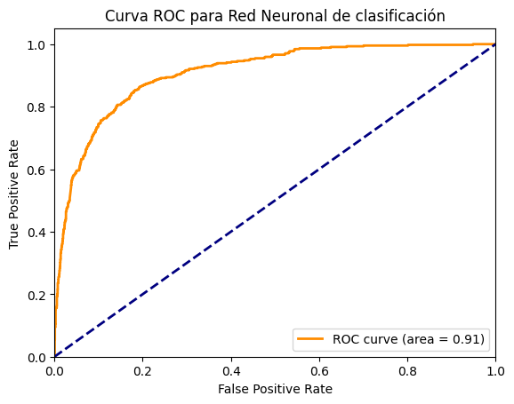

```python
plt.figure()
plt.plot(fpr, tpr, color='darkorange', lw=2, label=f'ROC curve (area = {roc_auc:.2f})')
plt.plot([0, 1], [0, 1], color='navy', lw=2, linestyle='--')
plt.xlim([0.0, 1.0])
plt.ylim([0.0, 1.05])
plt.xlabel('False Positive Rate')
plt.ylabel('True Positive Rate')
plt.title('Curva ROC para Red Neuronal de clasificación')
plt.legend(loc="lower right")
plt.show()
```

De esta curva ROC y su área (0.91) se deduce algo que ya veíamos con las métricas de la red neuronal: el modelo es capaz de acertar la mayoría de positivos que predice, es decir, tiene una alto rate de True Positive, y se equivoca poco cuando predice los negativos (ya que la tasa de falsos positivos indica la proporción de negativos predichos como positivos respecto del total de negativos).

A pesar de esta aparente solidez, esta relación TPRate y FPRate no incluye la información de los positivos que se quedaron sin predecir bien, es decir, los falsos negativos. El recall del modelo es de 0.58, lo que nos indica que, aunque es capaz de errar poco al predecir los positivos, se deja muchos por el camino, y esto, en este contexto, no es algo aceptable.

Por lo tanto, y como conclusión final: se considera este trabajo una primera iteración de la que se ha podido sacar información valiosa (por ejemplo, respecto de las distribuciones de las variables, o de sus correlaciones), y en la que se han realizado transformaciones de variables interesantes y empleado modelos de reducción de las mismas que pueden reutilizarse en una seguna iteración. Se recomendaría para esta segunda iteración tratar de usar distintos métodos de reducción de variables (por ejemplo, se podría probar el método *stepwise*) y se recomienda encarecidamente tratar los problemas de desbalanceo de variables, bien mediante métodos para generar datos aleatorios de las clases minoritarias, o bien mediante la eliminación (en caso de estar justificado) de las variables más desbalanceadas, si fuera necesario.

Finalmente, a pesar de los resultados no tan buenos, la elección de los modelos no se considera errónea, de modo que podrían volver a emplearse los mismos códigos en una segunda iteración, ya que, tanto la regresión logística como la red neuronal para clasificación y el random forest aplicado en problemas de clasificación, son modelos que deben funcionar bien para el propósito de la empresa de predecir una variable binaria y sus probabilidades.